# Smoking and COVID Living Review

David Simons, Lion Shahab, Jamie Brown and Olga Perski

Friday 26 June 2020

## 0.1 Data preparation

### 0.1.1 Load packages

- **Load packages**: load packages and useful scripts for the analysis

```r
library('tidyverse', quietly = T)
library('ggplot2', quietly = T)
library('dplyr', quietly = T)
library('readxl', quietly = T)
library('linelist', quietly = T)
library('googlesheets4', quietly = T)
library('naniar', quietly = T)
library('gridExtra', quietly = T)
library('snakecase', quietly = T)
library('epitools', quietly = T)
library('meta', quietly = T)
library('knitr', quietly = T)
library('kableExtra', quietly = T)
library('snakecase', quietly = T)
library('here', quietly = T)
library('flextable', quietly = T)
library('DT', quietly = T)
```

### 0.1.2 Download from Google sheets

- **Load data**: import raw dataset directly from Google sheets We import the data from the dataset that is available in the “data for analysis” folder on the Google drive. This is available to be viewed with the [link](https://docs.google.com/spreadsheets/d/1AKSPbmGLuTcb5H47KBF--lJw66Vv5fuieYvdlwevrUc/edit?usp=sharing) and is only available for viewing not editing.

In future versions we may open a tab in the Google sheet to allow people to submit relevant papers for us to incorporate in our review.

```r
sheets_id <- as_sheets_id("https://docs.google.com/spreadsheets/d/1qoJT05r1jvkKj81-tnDLDN9Fe7bkVhhD-USTj7k5uRQ/edit?usp=sharing")
search_details <- read_sheet(sheets_id, range = 'article_screening')
data_study_general <- read_sheet(sheets_id, range =  'general_details')
table_1 <- read_sheet(sheets_id, sheet = 'pop_descriptives')
table_2 <-  read_sheet(sheets_id, sheet = 'testing')
table_3 <-  read_sheet(sheets_id, sheet = 'hospitalisation')
table_4 <-  read_sheet(sheets_id, sheet = 'severity')
table_5 <-  read_sheet(sheets_id, sheet = 'mortality')
table_6 <-  read_sheet(sheets_id, sheet = 'updated_quality_appraisal')
```

The data is downloaded from the sheet and split into dataframes to represent the current sheets and analysis.

### 0.1.3 Raw Data

The first sheet is **Search details** we use this sheet to keep track of the number of studies found in our search and keep track of the number of titles and abstracts screened and number of papers included in each review version. It presents the data in groups of search periods.

```r
flextable(head(search_details))
```

| date_screening in format (2020-05-22) | ovid_number_results | ovid_screened | ovid_excluded | ovid_included | medrxiv_number_results | medrxiv_screened | medrxiv_included | other_source_included | total_included | review_version | reason_no_smoking_data | reason_suspected_infection |
| --- | --- | --- | --- | --- | --- | --- | --- | --- | --- | --- | --- | --- |
| 2020-04-21 | 15 | NA | NA | 4 | NA | NA | NA | 24 | 28 | v1 | NA | NA |
| 2020-05-05 | 57 | 7 | 4 | 3 | 37 | 10 | 0 | 0 | 3 | v2 | NA | NA |
| 2020-05-16 | 67 | 12 | 12 | 0 | 70 | 64 | 22 | 6 | 28 | v3 | NA | NA |
| 2020-06-02 | 297 | 48 | 44 | 4 | 158 | 158 | 32 | 2 | 38 | v4 | NA | NA |
| 2020-06-23 | 477 | 72 | 63 | 6 | 157 | 157 | 41 | 2 | 49 | v5 | NA | NA |

The second sheet is **General study details** this includes the lead author, where the study is published, the date it was published, the country in which the data originated and the DoI or link to the publication for our records.

The third sheet is termed **Table 1** this contains the details of the population of the study in relation to our review. Predominantly smoking status but also the proportion of females in the study and the age of participants.

The fourth sheet is termed **Table 2** this contains the data extracted from relevant studies on testing data and smoking status. Most studies will not have data on this outcome however we filter these subsequently. These are sparse datasets as many studies do not report on all levels of smoking exposure.

The fourth sheet is termed **Table 3** this contains the data extracted from relevant studies on hospitalisation and smoking status.

The fourth sheet is termed **Table 4** this contains the data extracted from relevant studies disease severity data and smoking status. Disease severity is differentially reported across the studies in some there is reference to WHO severity score in others we have based the distinction on clinical characteristics or whether patients were admitted to Intensive or Critical care areas.

The fifth sheet is termed **Table 5** this contains the data extracted from relevant studies on COVID-19 related mortality and smoking status. A caution needed when interpreting this data is that most studies have not followed patients up for sufficient amounts of time to be able to accurately report on disease associated mortality.

The final sheet was used to collate data on **Study quality** however, we have discontinued the use of this tool from version 3 due to the large number of components that were unable to be assessed in the rapidly expanding area of COVID-19 related research.

### 0.1.4 Clean data and save updated versions as RDS files

The data from the google sheets document is then cleaned using a script from the `linelist` package which has been developed by T. Jombat and Z. Kamvar within the [R Epidemics Consortium](https://www.repidemicsconsortium.org/)

The script `clean_data()` ensures consistency among column names, country names, dates and missing values in the included sheets. Data is also saves as `.rds` files in the `/data_clean` folder of the project directory.

```r
search_details <- search_details %>%
  clean_data() %>%
  rename(date_screened = date_screening_in_format_2020_05_22) %>%
  write_rds(here::here('data_clean', 'search_details.rds')) ## The title of the date screened column is to communicate among the review team how we need date formatted

protect_columns_1 <- names(data_study_general) %in% 'doi' ## As the DoI's are links we want to preserve their formatting when running the cleaning script

data_study_general <- data_study_general %>%
  rename('notes' = 11, date_published = `date_published_format(2020-05-12)`) %>%
  clean_data(protect = protect_columns_1) %>%
  mutate(study_id = 1:length(lead_author)) %>% ## We create a unique study ID to aid checking of the outputs later
  write_rds(here::here('data_clean', 'data_study_general.rds'))

review_details <- data_study_general %>%
  select(lead_author, date_published, country, review_version, study_id) %>% ## The version of the review in which included studies were incorporated is noted
  write_rds(here::here('data_clean', 'review_details.rds'))

table_1 <- table_1 %>%
  clean_data() %>%
  mutate(., lower_range = sub('\\_.*', '', .$range)) %>%
  mutate(., upper_range = sub('.*_', '',.$range,)) %>% ## We break apart the age range into an upper and lower level
  select(lead_author, sample_size, female_sex_percent, data_source, median_age, mean_age, iqr_lower, iqr_upper, standard_deviation, lower_range,
         upper_range, current_smoker, former_smoker, current_former_smoker, never_smoker, never_smoker_unknown, current_vaper, former_vaper,
         current_former_vaper, not_stated, missing, total) %>%
  filter(!is.na(lead_author)) %>%
  left_join(., review_details, by = 'lead_author') %>%
  write_rds(here::here('data_clean', 'table_1.rds'))


##For the following tables we're only interested in obtaining data for trials which report on the specific outcome of interest

table_2 <-  table_2 %>%
  clean_data() %>%
  filter(data_on_testing == TRUE) %>%
  left_join(., review_details, by = 'lead_author') %>%
  write_rds(here::here('data_clean', 'table_2.rds'))

table_3 <-  table_3 %>%
  clean_data() %>%
  filter(data_on_hospitalisation == TRUE) %>%
  left_join(., review_details, by = 'lead_author') %>%
  write_rds(here::here('data_clean', 'table_3.rds'))

table_4 <-  table_4 %>%
  clean_data() %>%
  filter(data_disease_severity == TRUE) %>%
  left_join(., review_details, by = 'lead_author') %>%
  write_rds(here::here('data_clean', 'table_4.rds'))

table_5 <- table_5 %>%
  clean_data() %>%
  filter(data_on_deaths == TRUE) %>%
  left_join(., review_details, by = 'lead_author') %>%
  write_rds(here::here('data_clean', 'table_5.rds'))


protect_columns_2 <- !names(table_6) %in% 'lead_author'

table_6 <-  table_6 %>%
  clean_data(protect = protect_columns_2) %>%
  left_join(., table_1 %>%
              select(lead_author,
                     not_stated,
                     missing,
                     total),
                          by = 'lead_author') %>%
  mutate(missingness = rowSums(.[8:9], na.rm = T),
         missingness_percentage = (missingness/total)*100) %>% ## Later we want to assess the amount of missingness for each study as it would impact the inclusion of a study into the relevant meta-analyses
  select(-c(not_stated, missing, total, missingness)) %>%
  write_rds(here::here('data_clean', 'table_6.rds'))

a <- data_study_general %>%
  select(lead_author, date_published, source, study_id) %>%
  rename('Lead Author' = lead_author,
         'Date Published' = date_published,
         'Publication Source' = source,
         'Study ID' = study_id)

a$`Lead Author` <- to_upper_camel_case(a$`Lead Author`, sep_out = ", ")
a$`Publication Source` <- to_title_case(a$`Publication Source`)
a$`Publication Source` <- if_else(str_length(a$`Publication Source`) < 5,
                                  toupper(a$`Publication Source`),
                                  to_title_case(a$`Publication Source`))
```

This is a table containing all studies included in the google sheets document. We only perform analysis on a subset of these studies due to there being for example duplication of reports such as the ISARIC reports or superseeded and retracted articles.

## 0.2 Preparing the descriptive analysis

### 0.2.1 Choosing which data we want to include in the current review?

We define the current version of the report here. At the moment this needs to be changed directly in the underlying code.

```r
date_of_update <- Sys.Date()

prev_versions <- c('v1', 'v2', 'v3', 'v4')
#This can categorise which studies we want to look at
current_version <- c('v5')
#This will categorise which studies we are including in the current report

analysed_versions <- c('v1', 'v2', 'v3', 'v4', 'v5')
#This will incorporate all studies into the current version of the report
```

As we don’t want to remove studies from the dataset despite them no longer being included the excluded studies are defined in this chunk of code.

```r
exclude_from_analysis <- c('isaric_1', 'isaric_2', 'isaric_3', 'miyara_old', 'isaric_4', 'mehra', 'hopkinson', 'gaibazzi', 'miyara_updated', 'russell')
```

We have excluded from the analysis the following studies: isaric_1, isaric_2, isaric_3, miyara_old, isaric_4, mehra, hopkinson, gaibazzi, miyara_updated, and russell

As a sense check this line pulls in the defined current version, which is: **v5**.

### 0.2.2 Filter the included studies

Based on the version and excluded studies we produce the tables for analysis. These are shown below.

```r
data_study_general <- data_study_general %>%
  filter(review_version %in% analysed_versions) %>%
  filter(!(lead_author %in% exclude_from_analysis)) %>%
  write_csv(., here::here('data_clean', 'data_study_general.csv'))

table_1 <- table_1 %>%
  filter(review_version %in% analysed_versions) %>%
  select(-review_version) %>%
  filter(!(lead_author %in% exclude_from_analysis))

table_2 <- table_2 %>%
  filter(review_version %in% analysed_versions) %>%
  select(-review_version) %>%
  filter(!(lead_author %in% exclude_from_analysis))

table_3 <- table_3 %>%
  filter(review_version %in% analysed_versions) %>%
  select(-review_version) %>%
  filter(!(lead_author %in% exclude_from_analysis))

table_4 <- table_4 %>%
  filter(review_version %in% analysed_versions) %>%
  select(-review_version) %>%
  filter(!(lead_author %in% exclude_from_analysis))

table_5 <- table_5 %>%
  filter(review_version %in% analysed_versions) %>%
  select(-review_version) %>%
  filter(!(lead_author %in% exclude_from_analysis))

a <- data_study_general %>%
  select(lead_author, date_published, source, study_id) %>%
  rename('Lead Author' = lead_author,
         'Date Published' = date_published,
         'Publication Source' = source,
         'Study ID' = study_id)

a$`Lead Author` <- to_upper_camel_case(a$`Lead Author`, sep_out = ", ")
a$`Publication Source` <- to_title_case(a$`Publication Source`)
a$`Publication Source` <- if_else(str_length(a$`Publication Source`) < 5,
                                  toupper(a$`Publication Source`),
                                  to_title_case(a$`Publication Source`))

datatable(a)
```

|  | Lead Author | Date Published | Publication Source | Study ID |
| --- | --- | --- | --- | --- |
| 1 | Guan, Ni | 2020-02-28 | NEJM | 1 |
| 2 | Guan, Liang | 2020-03-26 | European Respiratory Journal | 2 |
| 3 | Lian | 2020-03-25 | Clinical Infectious Diseases | 3 |
| 4 | Jin | 2020-03-24 | Gastroduodenal | 4 |
| 5 | Chen | 2020-03-26 | BMJ | 5 |
| 6 | Zhou, Yu | 2020-03-11 | The Lancet | 6 |
| 7 | Mo | 2020-03-16 | Clinical Infectious Diseases | 7 |
| 8 | Zhang, Dong | 2020-02-19 | Allergy | 8 |
| 9 | Wan | 2020-03-21 | Journal of Medical Virology | 9 |
| 10 | Liu, Tao | 2020-02-28 | Chinese Medical Journal | 10 |

[output cut: 138 more lines]

```r
a <- flextable(a)%>%
  set_table_properties(width = 1, layout = 'autofit') %>%
  set_caption(caption = 'Studies included in the current analysis')

save_as_docx(a, path = here('data_clean', 'included_studies.docx'))
```

## 0.3 Descriptive analysis

### 0.3.1 The PRISMA diagram will be updated with these numbers

```r
#Number screened to add to PRISMA
from_prev_version <- data_study_general %>%
  filter(review_version %in% prev_versions) %>%
  filter(!(lead_author %in% exclude_from_analysis)) %>%
  tally()

source(here::here('scripts', 'prisma_function.R'))

PRISMA_v5 <- PRISMA(search_details)
PRISMA_v5 <- as.data.frame(PRISMA_v5)
a <- PRISMA_v5 %>%
  t() %>%
  as.data.frame() %>%
  add_rownames() %>%
  flextable() %>%
  set_header_labels(rowname = 'PRISMA category',
                    V1 = 'Number of studies') %>%
  set_table_properties(width = 1, layout = 'autofit') %>%
  set_caption(caption = 'Data for PRISMA')

save_as_docx(a, path = here('data_clean', 'PRISMA_details.docx'))
a
```

Data for PRISMA

| PRISMA category | Number of studies |
| --- | --- |
| ovid_number_results | 477 |
| medrxiv_number_results | 157 |
| other_source_included | 2 |
| titles_screened | 636 |
| excluded_abstract | 405 |
| full_texts_reviewed | 231 |
| full_texts_excluded | 182 |
| full_texts_included_narrative | 49 |
| total_all_versions | 148 |

The numbers included in the quantitative analysis are based meeting quality eligibility criteria and are calculated by hand.

### 0.3.2 We summarise where the studies were conducted

As the pandemic continues studies are being reported from increasing numbers of countries.

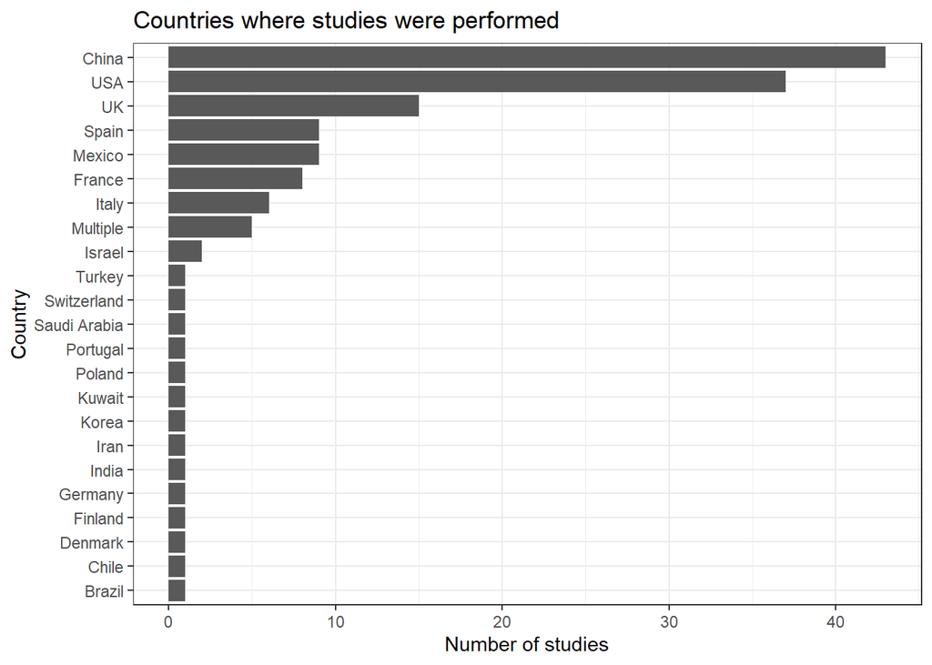

```r
library('ggmap')


#Countries
country <- table_1$country %>%
  to_upper_camel_case() %>%
  recode(., 'Usa' = 'USA', 'Uk' = 'UK', 'SaudiArabia' = 'Saudi Arabia') %>%
  table() %>%
  as.data.frame() %>%
  arrange(desc(Freq)) %>%
  rename('Country' = 1,
         'Number' = 2) %>%
  mutate(Country = as.character(Country))

ggplot(country, aes(x = reorder(Country, desc(-Number)), y = Number))+
  geom_col()+
  coord_flip()+
  theme_bw()+
  labs(title = 'Countries where studies were performed',
       y = 'Number of studies',
       x = 'Country')
```

```r
a <- flextable(country) %>%
  set_table_properties(width = 0.5, layout = 'autofit')
a
```

| Country | Number |
| --- | --- |
| China | 43 |
| USA | 37 |
| UK | 15 |
| Mexico | 9 |
| Spain | 9 |
| France | 8 |
| Italy | 6 |
| Multiple | 5 |
| Israel | 2 |
| Brazil | 1 |
| Chile | 1 |
| Denmark | 1 |
| Finland | 1 |
| Germany | 1 |
| India | 1 |
| Iran | 1 |
| Korea | 1 |
| Kuwait | 1 |
| Poland | 1 |
| Portugal | 1 |
| Saudi Arabia | 1 |
| Switzerland | 1 |
| Turkey | 1 |

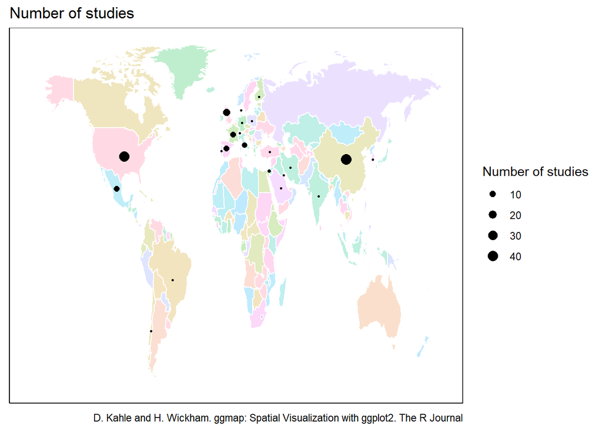

```r
country <- subset(country, Country != "Multiple")

country <- mutate_geocode(country, Country)

country_bounds <- country %>%
  select(lon, lat) %>%
  drop_na %>%
  sp::SpatialPointsDataFrame(coords = .[,1:2], data = .) %>%
  sp::bbox() * 1.1

map_world <- map_data(map = "world") %>%
  filter(region != "Antarctica")


study_countries <- ggplot() +
  geom_polygon(data = map_world,
               aes(long, lat, group = group, fill = region),
               show.legend = FALSE,
               alpha = 0.25,
               color = "white") +
  geom_point(data = country,
             aes(lon, lat, size = Number), shape = 20) +
  scale_size_continuous(name = "Number of studies") +
  theme_bw() +
  theme(axis.line = element_line(),
        panel.grid.major = element_blank(),
        panel.grid.minor = element_blank(),
        panel.background = element_blank(),
        axis.ticks = element_blank(),
        axis.title = element_blank(),
        axis.text = element_blank()) +
  labs(title = "Number of studies",
       caption = "D. Kahle and H. Wickham. ggmap: Spatial Visualization with ggplot2. The R Journal")
study_countries
```

```r
save_as_docx(a, path = here('data_clean', 'Countries_performing_studies.docx'))
```

### 0.3.3 We sumarise the settings in which they were conducted

Most studies are performed in hospital settings. Some studies are conducted in both such as those in emergency departments where patients are discharged home and followed up. Some registry studies utilising primary care networks are solely conducted in the community.

```r
#Setting
setting <- to_upper_camel_case(data_study_general$study_setting, sep_out = ' ') %>%
  table(.) %>%
  sort('Number of studies', decreasing = T) %>%
  as.data.frame() %>%
  arrange(desc(Freq)) %>%
  rename('Setting' = 1,
         'Number' = 2)

a <- flextable(setting) %>%
  set_table_properties(width = 0.5, layout = 'autofit')
a
```

| Setting | Number |
| --- | --- |
| Hospital | 105 |
| Community And Hospital | 34 |
| Community | 7 |
| Not Stated | 1 |
| Quarantine Centre | 1 |

```r
save_as_docx(a, path = here('data_clean', 'Countries_performing_studies.docx'))
```

### 0.3.4 We update the number of participants we have included

- **Summary statistics:** this table will give us the mean, median and IQR of the samples in the review

```r
#Numbers
a <- summary(table_1$sample_size)
a
```

```
##     Min.  1st Qu.   Median     Mean  3rd Qu.     Max.
##        7      106      326   127455     1122 17425445
```

- **Total number of participants**: 18863302

### 0.3.5 We want to know if they use a CRF or electronic health record

The majority of data on smoking outcomes is extracted from electronic health records that are routinely collected in the provision of healthcare. Some of the studies utilise specifically designed Case Report Forms (CRFs). The source of information on smoking status is not always reported.

```r
#Source of data
table_1$data_source %>%
  recode('electronic_health_records' = 'Electronic health record',
         'case_report_form' = 'Case report form',
         'not_stated' = 'Not stated') %>%
  table() %>%
  as.data.frame() %>%
  arrange(desc(Freq)) %>%
  rename('Data source' = 1,
         'Number' = 2) %>%
  flextable() %>%
  set_table_properties(width = 0.5, layout = 'autofit')
```

| Data source | Number |
| --- | --- |
| Electronic health record | 92 |
| Case report form | 35 |
| Not stated | 21 |

### 0.3.6 Now about the smoking

```r
#Studies reporting smokers
current_smok <- table_1 %>%
  filter(., current_smoker != 'NA')
```

- **Current smokers:** 87 studies report on the numbers of current smokers

```r
#Studies reporting former smokers
former_smok <- table_1 %>%
  filter(., former_smoker != 'NA')
```

- **Former smokers:** 42 studies report on the numbers of former smokers

```r
#Studies reporting never smokers
never_smok <- table_1 %>%
  filter(., never_smoker != 'NA')
```

- **Never smokers:** 44 studies report on the numbers of never smokers

```r
#Studies reporting current/former smokers
current_former_smok <- table_1 %>%
  filter(., current_former_smoker != 'NA')
```

- **Current/former smokers:** 60 studies report on the numbers of current/former smokers without distinguishing between them, often termed as yes to a smoking history question.

```r
#Studies reporting missing data
missing_smok <- table_1 %>%
  filter(., missing != 'NA') %>%
  mutate(percent = missing/total*100)
minimum <- min(missing_smok$percent)
maximum <- max(missing_smok$percent)
#Studies reporting never/unknown
never_smok_unknown <- table_1 %>%
  filter(., never_smoker_unknown != 'NA')

#Studies with not stated
smok_not_stated <- table_1 %>%
  filter(., not_stated != 'NA')
```

- **Missing, never/unknown and not stated:** studies report on the numbers of missing (48), never/unknown (12) or not stated (91) smoking history. This is often framed as absence of a smoking history.

**Minimum missing:** 0.0802890405459655 **Maximum missing:** 96.3557665456576

```r
#Studies reporting current, former and never smoking status
full_smoking_status <- table_1 %>%
  filter(lead_author %in% current_smok$lead_author) %>%
  filter(lead_author %in% former_smok$lead_author) %>%
  filter(lead_author %in% never_smok$lead_author)

b <- full_smoking_status %>%
  select(lead_author, sample_size, current_smoker, former_smoker, never_smoker, study_id) %>%
  rename('Lead author' = lead_author,
         'Sample size' = sample_size,
         'Current smokers' = current_smoker,
         'Former smokers' = former_smoker,
         'Never smokers' = never_smoker,
         'Study ID' = study_id)

b$`Lead author` <- to_upper_camel_case(b$`Lead author`, sep_out = ", ")

datatable(b,
          caption = "Studies providing data on current, former and never smokers") %>%
  formatRound(columns = c(2:5), digits = 0, interval = 3, mark = ",")
```

|  | Lead author | Sample size | Current smokers | Former smokers | Never smokers | Study ID |
| --- | --- | --- | --- | --- | --- | --- |
| 1 | Guan, Ni | 1099 | 137 | 21 | 927 | 1 |
| 2 | Rentsch | 3528 | 159 | 179 | 216 | 18 |
| 3 | Argenziano | 1000 | 49 | 179 | 772 | 29 |
| 4 | Hadjadj | 50 | 1 | 9 | 40 | 38 |
| 5 | Niedzwiedz | 1474 | 42745 | 147235 | 235711 | 39 |
| 6 | Cho | 1331 | 253 | 359 | 719 | 51 |
| 7 | Robilotti | 423 | 9 | 159 | 248 | 53 |
| 8 | Opensafely, Collaborative | 17425445 | 2962373 | 5737545 | 8000204 | 54 |
| 9 | Shah | 316 | 52 | 56 | 133 | 57 |
| 10 | Kolin | 1474 | 213 | 592 | 657 | 59 |

[output cut: 22 more lines]

```r
#These are the studies with data on current, former and never smokers
```

- **Studies with complete smoking status:** 32

```r
#Studies reporting current or current/former and never smoking
semi_full_smoking_status <- table_1 %>%
  filter(lead_author %in% current_former_smok$lead_author) %>%
  filter(lead_author %in% never_smok$lead_author) %>%
  filter(!lead_author %in% full_smoking_status$lead_author)

b <- semi_full_smoking_status %>%
  select(lead_author, sample_size, current_former_smoker, never_smoker, study_id) %>%
  rename('Lead author' = lead_author,
         'Sample size' = sample_size,
         'Current/former smokers' = current_former_smoker,
         'Never smokers' = never_smoker,
         'Study ID' = study_id)

b$`Lead author` <- to_upper_camel_case(b$`Lead author`, sep_out = ", ")

datatable(b,
          caption = "Studies providing partially complete data on smoking status") %>%
  formatRound(columns = c(2:4), digits = 0, interval = 3, mark = ",")
```

|  | Lead author | Sample size | Current/former smokers | Never smokers | Study ID |
| --- | --- | --- | --- | --- | --- |
| 1 | Guan, Liang | 1590 | 111 | 1479 | 2 |
| 2 | Richardson | 5700 | 558 | 3009 | 31 |
| 3 | Rodriguez | 7 | 3 | 4 | 35 |
| 4 | Zheng, Xiong | 73 | 8 | 65 | 45 |
| 5 | Giacomelli | 233 | 70 | 163 | 56 |
| 6 | Palaiodimos | 200 | 65 | 135 | 82 |
| 7 | Gianfrancesco | 600 | 129 | 389 | 97 |
| 8 | Ramlall | 11116 | 2979 | 8137 | 113 |
| 9 | Mcqueenie | 428199 | 189968 | 235698 | 126 |
| 10 | Hultcrantz | 127 | 34 | 92 | 130 |

[output cut: 1 more lines]

**Studies reporting partially incomplete smoking data:** 11

```r
#Remaining studies
incomplete_smoking_status <- table_1 %>%
  filter(!lead_author %in% full_smoking_status$lead_author) %>%
  filter(!lead_author %in% semi_full_smoking_status$lead_author)

b <- incomplete_smoking_status %>%
  select(lead_author, sample_size, current_smoker, current_former_smoker, former_smoker, never_smoker, never_smoker_unknown, not_stated, missing, study_id) %>%
  rename('Lead author' = lead_author,
         'Sample size' = sample_size,
         'Current smokers' = current_smoker,
         'Current/former smokers' = current_former_smoker,
         'Former smoker' = former_smoker,
         'Never smokers' = never_smoker,
         'Never smoker/unknown' = never_smoker_unknown,
         'Not stated' = not_stated,
         'Missing' = missing,
         'Study ID' = study_id)

b$`Lead author` <- to_upper_camel_case(b$`Lead author`, sep_out = ", ")

datatable(b,
          caption = "Studies providing incomplete data on smoking status") %>%
  formatRound(columns = c(2:8), digits = 0, interval = 3, mark = ",")
```

|  | Lead author | Sample size | Current smokers | Current/former smokers | Former smoker | Never smokers | Never smoker/unknown | Not stated | Missing | Study ID |
| --- | --- | --- | --- | --- | --- | --- | --- | --- | --- | --- |
| 1 | Lian | 788 | 54 |  |  |  |  | 734 |  | 3 |
| 2 | Jin | 651 | 41 |  |  |  |  | 610 |  | 4 |
| 3 | Chen | 548 | 24 |  | 14 |  |  | 510 |  | 5 |
| 4 | Zhou, Yu | 191 | 11 |  |  |  |  | 180 |  | 6 |
| 5 | Mo | 155 | 6 |  |  |  |  | 149 |  | 7 |
| 6 | Zhang, Dong | 140 | 2 |  | 7 |  |  | 131 |  | 8 |
| 7 | Wan | 135 | 9 |  |  |  |  | 126 |  | 9 |
| 8 | Liu, Tao | 78 |  | 5 |  |  |  | 73 |  | 10 |
| 9 | Huang, Wang | 41 | 3 |  |  |  |  | 38 |  | 11 |
| 10 | Zhang, Cai | 645 | 41 |  |  |  |  | 604 |  | 12 |

[output cut: 95 more lines]

**Studies missing key smoking data:** 105

## 0.4 Smoking prevalence by country

```r
#Smoking prevalence by country
country_prevalence_list <- table_1 %>%
    group_by(country, add = T) %>%
  mutate(., current_smok_percentage = current_smoker/total*100) %>%
  mutate(., former_smok_percentage = former_smoker/total*100) %>%
  mutate(., missing_percentage = missing/total*100) %>%
  mutate(., not_stated_percentage = not_stated/total*100) %>%
  mutate(never_smoker_percentage = never_smoker/total*100) %>%
  group_split()
```

We have split the data into a list where each country can be analysed separately if required

#### 0.4.0.1 Graph for smoking prevalence in the countries included

If this is the first time generating this report the bootstrapping script `olgas_script.R` needs to be run in order to generate the 95% confidence intervals around the point estimates from the included studies. Following the production of the confidence intervals the prevalence graphs are produced in the `smoking_plots.R` script. This uses data extracted on current and former smoking prevalence data from countries which have included studies in this review. If this version has previously been produced graphs will be loaded directly from a cache.

**Current smoking prevalence** Two plots are produced. The first for current smoking prevalence, here the size of the dot corresponds to the size of the study. The studies are grouped by the country in which they were conducted. The solid line represents national current smoking prevalence obtained from national smoking survey estimates. The dashed line represents the weighted mean of the current smoking prevalence in the included studies.

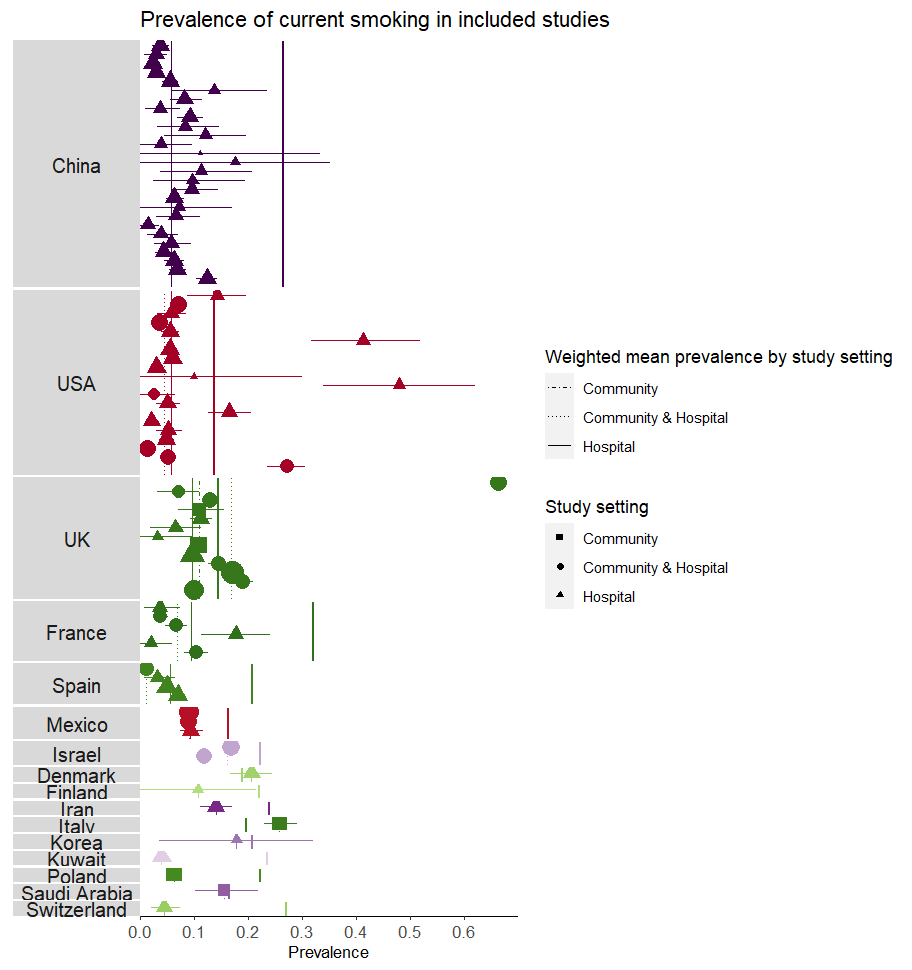

Country smoking prevalence

**Former smoker prevalence** This graph is for former smoking prevalence. The data is more sparse for this exposure and therefore several countries are missing for the analysis.

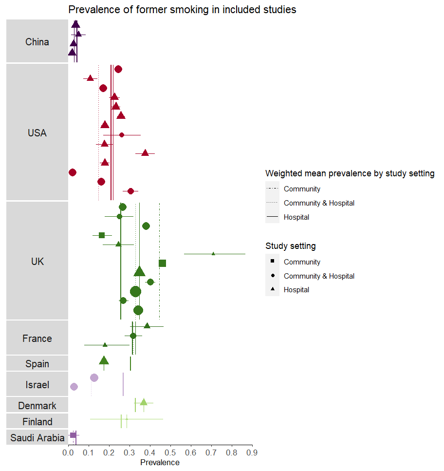

## 0.5 Final results tables and meta-analyses

### 0.5.1 Table 1: Included studies

```r
#Updating table 1
table_1_word <- table_1 %>%
  mutate(., current_percentage = current_smoker/total*100,
         former_percentage = former_smoker/total*100,
         current_former_percentage = current_former_smoker/total*100,
         never_smoker_percentage = never_smoker/total*100,
         never_smoker_unknown_percentage = never_smoker_unknown/total*100,
         not_stated_percentage = not_stated/total*100,
         missing_percentage = missing/total*100) %>%
  select(lead_author, date_published, country, sample_size, median_age, iqr_lower, iqr_upper, mean_age, lower_range,
         upper_range, standard_deviation, female_sex_percent, current_percentage, former_percentage, current_former_percentage,
         never_smoker_percentage, never_smoker_unknown_percentage, not_stated_percentage, missing_percentage, study_id) %>%
  replace_na(., list(not_stated_percentage = 0, missing_percentage = 0)) %>%
  mutate(., missing_percentage = not_stated_percentage + missing_percentage,
         missing_percentage = formatC(missing_percentage, digits = 2, format = "f"))

#Smoking completeness
smoking_status <- as_tibble(full_smoking_status$lead_author) %>%
  rename(lead_author = 1) %>%
  mutate(complete_status = c("Yes")) %>%
  bind_rows(., semi_full_smoking_status %>%
              select(lead_author)) %>%
  bind_rows(., incomplete_smoking_status %>%
              select(lead_author)) %>%
  distinct() %>%
  mutate(complete_status = replace_na(complete_status, "No"))

#Data missingness
missingness <- table_6 %>%
  select(lead_author) %>%
  left_join(., table_1_word %>%
              select(lead_author, missing_percentage)) %>%
  mutate(missing_percentage = as.numeric(missing_percentage),
         low_missingness = ifelse(missing_percentage >= 20, "No", "Yes"))

#Defining poor quality
poor_quality <- missingness %>%
  select(-missing_percentage) %>%
  left_join(., smoking_status, by = "lead_author") %>%
  mutate(study_quality = ifelse(low_missingness == "No" | complete_status == "No", "Poor", "Not_poor"))

good_quality <- table_6 %>%
  left_join(., poor_quality, by = "lead_author") %>%
  select(lead_author, study_quality, biochemical_verification, random_representative_sample) %>%
  mutate(study_quality_final = ifelse(study_quality == "Not_poor" & (biochemical_verification == "Yes" | random_representative_sample == "Yes"), "good",
                                      ifelse(study_quality == "Poor", "poor", "fair")))

quality_rating <- good_quality %>%
  select(lead_author, study_quality_final) %>%
  rename("overall_quality" = study_quality_final)

table_1_word <- left_join(table_1_word, good_quality %>%
                            select(lead_author, study_quality_final))


a <- data_study_general %>%
  select(study_id, study_setting)

table_1_word <- left_join(table_1_word, a, by = 'study_id') %>%
  select(1:4, 22, 5:19, 21, 20)
table_1_word$date_published <- as.Date.character(table_1_word$date_published)
write_rds(table_1_word, here::here('data_clean', 'table_1_word.rds'))

table_1_word <- table_1_word %>%
  mutate(median_mean = ifelse(is.na(median_age), mean_age, median_age))


a <- table_1_word %>%
  mutate(median_mean = ifelse(is.na(median_age), mean_age, median_age),
         mean_used = ifelse(is.na(mean_age), '','^'),
         iqr = ifelse(is.na(iqr_lower), NA, paste(iqr_lower, iqr_upper, sep = '-')),
         range_combined = paste(lower_range, upper_range, sep = '-'),
         range_combined = na_if(range_combined, 'NA-NA'),
         standard_deviation = as.numeric(standard_deviation),
         st_dev = paste((as.integer(median_mean-standard_deviation)), as.integer((median_mean+standard_deviation)), sep = '-'),
         st_dev = na_if(st_dev, 'NA-NA'))

a$iqr <- coalesce(a$iqr, a$range_combined, a$st_dev)
a$iqr_used <- coalesce(a$range_used, a$st_dev_used)

a <- a %>%
  select(study_id, lead_author, date_published, country, sample_size, study_setting, median_mean, mean_used, iqr,
         female_sex_percent, current_percentage, current_former_percentage, never_smoker_percentage,
         never_smoker_unknown_percentage, missing_percentage, study_quality_final) %>%
  mutate(median_mean = paste(median_mean, mean_used, sep = ''),
         median_mean = na_if(median_mean, NA)) %>%
  select(-mean_used) %>%
  mutate(median_mean = ifelse(median_mean == 'NA', 'NA', paste(paste(median_mean, iqr, sep = ' ('),')', sep = ''))) %>%
  select(-iqr) %>%
  rename('Study ID' = study_id,
         'Lead author' = lead_author,
         'Date published' = date_published,
         'Country' = country,
         'Sample size' = sample_size,
         'Study setting' = study_setting,
         'Median (IQR)' = median_mean,
         'Female %' = female_sex_percent,
         'Current smoker %' = current_percentage,
         'Current/former smokers %' = current_former_percentage,
         'Never smokers %' = never_smoker_percentage,
         'Never/unknown smokers %' = never_smoker_unknown_percentage,
         'Missing %' = missing_percentage,
         "Study quality" = study_quality_final)

a$`Lead author` <- to_upper_camel_case(a$`Lead author`, sep_out = ", ")

cleaned_names <- c('Chow, Us, Cdc',
                   "Gold, Us, Cdc",
                   "Miyara, Updated",
                   "De, La, Rica",
                   "Opensafely, Collaborative",
                   "Bello, Chavolla",
                   "Carrillo, Vega",
                   "De, Lusignan",
                   "Mejia, Vilet",
                   "Heili, Frades",
                   "Vaquero, Roncero",
                   "Al, Hindawi",
                   "Del, Valle",
                   "Soto, Mota",
                   "Eugen, Olsen",
                   "Martinez, Portilla",
                   "Raisi, Estabragh",
                   "Miyara, Medrxiv",
                   "Hernandez, Gardano",
                   "Siso, Almirall",
                   "Martinez, Jiminez",
                   "eugen_olsen",
                   "Mcqueenie")

correct_names <- c('Chow (US CDC)',
                   "Gold (US CDC)",
                   "Miyara",
                   "de la Rica",
                   "The Opensafely Collaborative",
                   "Bello-Chavolla",
                   "Carillo-Vega",
                   "de Lusignan",
                   "Mejia-Vilet",
                   "Heili-Frades",
                   "Vaquero-Roncero",
                   "Al-Hindawi",
                   "del Valle",
                   "Soto-Mota",
                   "Eugen-Olsen",
                   "Martinez-Portilla",
                   "Raisi-Estabragh",
                   "Miyara",
                   "Hernandez-Gardano",
                   "Siso-Almirall",
                   "Martinez-Jiminez",
                   "Eugen-Olsen",
                   "McQueenie")

author_list <- plyr::mapvalues(a$`Lead author`,
                               from = cleaned_names,
                               to = correct_names)

a$`Lead author` <- author_list

a$`Study setting` <-to_title_case(a$`Study setting`, sep_out = " ")
a$`Country` <-to_title_case(a$`Country`, sep_out = " ")
a$`Country` <- a$Country %>%
  recode('Usa' = 'USA',
         'Uk' = 'UK')

numeric_columns <- c('Median (IQR)', 'Female %', 'Current smoker %', 'Current/former smokers %',
                     'Never smokers %', 'Never/unknown smokers %', 'Missing %')

datatable(a) %>%
  formatRound(
    columns = c(8:14),
    digits = 2,
    interval = 3,
    mark = ",",
    dec.mark = getOption("OutDec")
)
```

|  | Study ID | Lead author | Date published | Country | Sample size | Study setting | Median (IQR) | Female % | Current smoker % | Current/former smokers % | Never smokers % | Never/unknown smokers % | Missing % | Study quality |
| --- | --- | --- | --- | --- | --- | --- | --- | --- | --- | --- | --- | --- | --- | --- |
| 1 | 1 | Guan, Ni | 2020-02-28 | China | 1099 | Hospital | 47 (35-58) | 41.9 | 12.4658780709736 |  | 84.3494085532302 |  | 1.27 | fair |
| 2 | 2 | Guan, Liang | 2020-03-26 | China | 1590 | Hospital | 49 (33-64) | 42.7 |  | 6.9811320754717 | 93.0188679245283 |  | 0.00 | poor |
| 3 | 3 | Lian | 2020-03-25 | China | 788 | Hospital | NA | 38.5 | 6.85279187817259 |  |  |  | 93.15 | poor |
| 4 | 4 | Jin | 2020-03-24 | China | 651 | Hospital | 46 (32-60) | 49.2 | 6.29800307219662 |  |  |  | 93.70 | poor |
| 5 | 5 | Chen | 2020-03-26 | China | 548 | Hospital | 62 (44-70) | 37.6 | 4.37956204379562 |  |  |  | 93.07 | poor |
| 6 | 6 | Zhou, Yu | 2020-03-11 | China | 191 | Hospital | 56 (46-67) | 38 | 5.75916230366492 |  |  |  | 94.24 | poor |
| 7 | 7 | Mo | 2020-03-16 | China | 155 | Hospital | 54 (53-66) | 44.5 | 3.87096774193548 |  |  |  | 96.13 | poor |
| 8 | 8 | Zhang, Dong | 2020-02-19 | China | 140 | Hospital | 57^ (25-87) | 46.3 | 1.42857142857143 |  |  |  | 93.57 | poor |
| 9 | 9 | Wan | 2020-03-21 | China | 135 | Hospital | 47 (36-55) | 46.7 | 6.66666666666667 |  |  |  | 93.33 | poor |
| 10 | 10 | Liu, Tao | 2020-02-28 | China | 78 | Hospital | 38 (33-57) | 50 |  | 6.41025641025641 |  |  | 93.59 | poor |

[output cut: 138 more lines]

```r
a
```

```
## # A tibble: 148 x 14
##    `Study ID` `Lead author` `Date published` Country `Sample size` `Study setting` `Median (IQR)` `Female %` `Current smoker~ `Current/former~ `Never smokers ~ `Never/unknown ~
##         <int> <chr>         <date>           <chr>           <dbl> <chr>           <chr>               <dbl>            <dbl>            <dbl>            <dbl>            <dbl>
##  1          1 Guan, Ni      2020-02-28       China            1099 Hospital        47 (35-58)           41.9            12.5             NA                84.3               NA
##  2          2 Guan, Liang   2020-03-26       China            1590 Hospital        49 (33-64)           42.7            NA                6.98             93.0               NA
##  3          3 Lian          2020-03-25       China             788 Hospital        NA                   38.5             6.85            NA                NA                 NA
##  4          4 Jin           2020-03-24       China             651 Hospital        46 (32-60)           49.2             6.30            NA                NA                 NA
##  5          5 Chen          2020-03-26       China             548 Hospital        62 (44-70)           37.6             4.38            NA                NA                 NA
##  6          6 Zhou, Yu      2020-03-11       China             191 Hospital        56 (46-67)           38               5.76            NA                NA                 NA
##  7          7 Mo            2020-03-16       China             155 Hospital        54 (53-66)           44.5             3.87            NA                NA                 NA
##  8          8 Zhang, Dong   2020-02-19       China             140 Hospital        57^ (25-87)          46.3             1.43            NA                NA                 NA
##  9          9 Wan           2020-03-21       China             135 Hospital        47 (36-55)           46.7             6.67            NA                NA                 NA
## 10         10 Liu, Tao      2020-02-28       China              78 Hospital        38 (33-57)           50              NA                6.41             NA                 NA
## # ... with 138 more rows, and 2 more variables: `Missing %` <chr>, `Study quality` <chr>
```

```r
a <- flextable(a) %>%
    set_caption(caption = 'Characteristics of included studies') %>%
  colformat_num(col_keys = numeric_columns, digits = 1, na_str = '-', big.mark = ',') %>%
  colformat_num(col_keys = 'Sample size', digits = 0, na_str = '-', big.mark = ',') %>%
  set_table_properties(width = 1, layout = 'autofit')

save_as_docx(a, path = here('data_clean', 'Table_1.docx'))
```

### 0.5.2 Table 2: Smoking and COVID-19 diagnostic testing

```r
#Table 2
table_2_word <-  table_2 %>%
  mutate(., sample = contributing_sample) %>%
  mutate(., negative_test_percentage =formatC(negative_test/sample*100, digits = 2, format = "f"),
         negative_current_percentage = formatC(negative_current_smoker/negative_test*100, digits = 2, format = "f"),
         negative_former_smoker_percentage = formatC(negative_former_smoker/negative_test*100, digits = 2, format = "f"),
         negative_current_former_smoker_percentage = formatC(negative_current_former_smoker/negative_test*100, digits = 2, format = "f"),
         negative_never_smoker_percentage = formatC(negative_never_smoker/negative_test*100, digits = 2, format = "f"),
         negative_not_stated_percentage = formatC(negative_not_stated/negative_test*100, digits = 2, format = "f"),
         positive_test_percentage = formatC(positive_test/sample*100, digits = 2, format = "f"),
         positive_current_smoker_percentage = formatC(positive_current_smoker/positive_test*100, digits = 2, format = "f"),
         positive_former_smoker_percentage = formatC(positive_former_smoker/positive_test*100, digits = 2, format = "f"),
         positive_current_former_smoker_percentage = formatC(positive_current_former_smoker/positive_test*100, digits = 2, format = "f"),
         positive_never_smoker_percentage = formatC(positive_never_smoker/positive_test*100, digits = 2, format = "f"),
         positive_not_stated_percentage = formatC(positive_not_stated/positive_test*100, digits = 2, format = "f")) %>%
  select(-data_on_testing, -missing, -date_published, -sample) %>%
  write_rds(here::here('data_clean', 'table_2_word.rds'))

quality_table_2 <- table_2_word %>%
  left_join(., quality_rating, by = 'lead_author')

a <- table_2_word %>%
  filter(contributing_sample >= 1) %>%
  mutate(Author = lead_author,
         Population_tested = contributing_sample,
         SARS_CoV_2_negative = paste(
           paste(negative_test,
                 (negative_test_percentage), sep = " ("), "%)", sep = ""),
         N_current_smoker = paste(paste(negative_current_smoker, (negative_current_percentage), sep = " (")
                                  , "%)", sep = ""),
         N_current_smoker = na_if(N_current_smoker, "NA ( NA%)"),
         N_former_smoker = paste(paste(negative_former_smoker, (negative_former_smoker_percentage), sep = " (")
                                 , "%)", sep = ""),
         N_former_smoker = na_if(N_former_smoker, "NA ( NA%)"),
         N_current_former_smoker = paste(paste(negative_current_former_smoker,
                                               (negative_current_former_smoker_percentage), sep = " (")
                                         , "%)", sep = ""),
         N_current_former_smoker = na_if(N_current_former_smoker, "NA ( NA%)"),
         N_never_smoker = paste(paste(negative_never_smoker,
                                      (negative_never_smoker_percentage), sep = " (")
                                , "%)", sep = ""),
         N_never_smoker = na_if(N_never_smoker, "NA ( NA%)"),
         N_not_stated = paste(paste(negative_not_stated,
                                    (negative_not_stated_percentage), sep = " (")
                              , "%)", sep = ""),
         N_not_stated = na_if(N_not_stated, "NA ( NA%)")) %>%
  mutate(SARS_CoV_2_positive = paste(
    paste(positive_test,
          (positive_test_percentage), sep = " ("), "%)", sep = ""),
    P_current_smoker = paste(paste(positive_current_smoker, (positive_current_smoker_percentage), sep = " (")
                             , "%)", sep = ""),
    P_current_smoker = na_if(P_current_smoker, "NA ( NA%)"),
    P_former_smoker = paste(paste(positive_former_smoker, (positive_former_smoker_percentage), sep = " (")
                            , "%)", sep = ""),
    P_former_smoker = na_if(P_former_smoker, "NA ( NA%)"),
    P_current_former_smoker = paste(paste(positive_current_former_smoker,
                                          (positive_current_former_smoker_percentage), sep = " (")
                                    , "%)", sep = ""),
    P_current_former_smoker = na_if(P_current_former_smoker, "NA ( NA%)"),
    P_never_smoker = paste(paste(positive_never_smoker,
                                 (positive_never_smoker_percentage), sep = " (")
                           , "%)", sep = ""),
    P_never_smoker = na_if(P_never_smoker, "NA ( NA%)"),
    P_not_stated = paste(paste(positive_not_stated,
                               (positive_not_stated_percentage), sep = " (")
                         , "%)", sep = ""),
    P_not_stated = na_if(P_not_stated, "NA ( NA%)")) %>%
  select(Author, Population_tested, SARS_CoV_2_negative, N_current_smoker, N_former_smoker, N_current_former_smoker,
         N_never_smoker, N_not_stated, SARS_CoV_2_positive, P_current_smoker, P_former_smoker, P_current_former_smoker,
         P_never_smoker, P_not_stated)


a$Author <- to_upper_camel_case(a$Author, sep_out = ", ")
a$Author  <- a$Author  %>%
  recode("Bello, Chavolla" = "Bello-Chavolla",
         "De, Lusignan" = "de Lusignan",
         "Del, Valle" = "del Valle")

numeric_columns <- c('Population_tested', 'SARS_CoV_2_negative', 'N_current_smoker', 'N_former_smoker',
                     'N_current_former_smoker', 'N_never_smoker', 'N_not_stated', 'SARS_CoV_2_positive', 'P_current_smoker',
                     'P_former_smoker', 'P_current_former_smoker', 'P_never_smoker', 'P_not_stated')
a <- flextable(a) %>%
    set_caption(caption = 'SARS-CoV-2 infection by smoking status') %>%
  colformat_num(col_keys = numeric_columns, digits = 0, na_str = '-', big.mark = ',')

a <- set_header_labels(a,
                       Population_tested = 'Total population tested',
                       SARS_CoV_2_negative = "N (%)",
                       N_current_smoker = "Current smoker (%)",
                       N_former_smoker = "Former smoker (%)",
                       N_current_former_smoker = "Current/former smoker (%)",
                       N_never_smoker = "Never smoker (%)",
                       N_not_stated = "Not stated (%)",
                       SARS_CoV_2_positive = "N (%)",
                       P_current_smoker = "Current smoker (%)",
                       P_former_smoker = "Former smoker (%)",
                       P_current_former_smoker = "Current/former smoker (%)",
                       P_never_smoker = "Never smoker (%)",
                       P_not_stated = "Not stated (%)") %>%
  add_header_row(top = TRUE, values = c("","SARS-CoV-2 negative", "SARS-CoV-2 positive" ), colwidths = c(2, 6, 6)) %>%
  theme_booktabs() %>%
  fix_border_issues() %>%
  set_table_properties(width = 1, layout = 'autofit')  %>%
  colformat_char(na_str = '-')
a
```

SARS-CoV-2 infection by smoking status

| Author | Total population tested | SARS-CoV-2 negative N (%) | SARS-CoV-2 negative Current smoker (%) | SARS-CoV-2 negative Former smoker (%) | SARS-CoV-2 negative Current/former smoker (%) | SARS-CoV-2 negative Never smoker (%) | SARS-CoV-2 negative Not stated (%) | SARS-CoV-2 positive N (%) | SARS-CoV-2 positive Current smoker (%) | SARS-CoV-2 positive Former smoker (%) | SARS-CoV-2 positive Current/former smoker (%) | SARS-CoV-2 positive Never smoker (%) | SARS-CoV-2 positive Not stated (%) |
| --- | --- | --- | --- | --- | --- | --- | --- | --- | --- | --- | --- | --- | --- |
| Rentsch | 3528 | 2974 (84.30%) | 1444 (48.55%) | 704 (23.67%) | - | 826 (27.77%) | - | 554 (15.70%) | 159 (28.70%) | 179 (32.31%) | - | 216 (38.99%) | - |
| Fontanet | 661 | 490 (74.13%) | 64 (13.06%) | - | - | 426 (86.94%) | - | 171 (25.87%) | 5 (2.92%) | - | - | 166 (97.08%) | - |
| Cho | 1331 | 793 (59.58%) | 142 (17.91%) | 214 (26.99%) | - | 437 (55.11%) | - | 538 (40.42%) | 111 (20.63%) | 145 (26.95%) | - | 282 (52.42%) | - |
| Shah | 243 | 212 (87.24%) | 52 (24.53%) | 47 (22.17%) | - | 113 (53.30%) | - | 29 (11.93%) | 0 (0.00%) | 9 (31.03%) | - | 20 (68.97%) | - |
| Bello-Chavolla | 62489 | 46960 (75.15%) | - | - | 4835 (10.30%) | - | 42125 (89.70%) | 15529 (24.85%) | - | - | 1374 (8.85%) | - | 14155 (91.15%) |
| Kolin | 1474 | 805 (54.61%) | 141 (17.52%) | 307 (38.14%) | - | 354 (43.98%) | 3 (0.37%) | 669 (45.39%) | 72 (10.76%) | 285 (42.60%) | - | 303 (45.29%) | 9 (1.35%) |
| de Lusignan | 3291 | 2740 (83.26%) | 366 (13.36%) | 1450 (52.92%) | - | 924 (33.72%) | - | 551 (16.74%) | 47 (8.53%) | 303 (54.99%) | - | 201 (36.48%) | - |
| Valenti | 789 | 689 (87.33%) | 197 (28.59%) | - | - | - | 492 (71.41%) | 40 (5.07%) | 7 (17.50%) | - | - | - | 33 (82.50%) |
| Parrotta | 76 | 39 (51.32%) | 1 (2.56%) | 10 (25.64%) | - | 27 (69.23%) | 1 (2.56%) | 37 (48.68%) | 1 (2.70%) | 10 (27.03%) | - | 25 (67.57%) | 1 (2.70%) |
| Berumen | 102875 | 71353 (69.36%) | - | - | 7173 (10.05%) | 64180 (89.95%) | - | 31522 (30.64%) | - | - | 2748 (8.72%) | 28774 (91.28%) | - |
| Israel | 24906 | 20755 (83.33%) | 3783 (18.23%) | 2671 (12.87%) | - | 14301 (68.90%) | - | 41151 (165.23%) | 406 (0.99%) | 483 (1.17%) | - | 3262 (7.93%) | - |
| del Valle | 1108 | 143 (12.91%) | 27 (18.88%) | 53 (37.06%) | - | - | 63 (44.06%) | 965 (87.09%) | 55 (5.70%) | 293 (30.36%) | - | - | 617 (63.94%) |
| Romao | 34 | 20 (58.82%) | - | - | 5 (25.00%) | - | 15 (75.00%) | 14 (41.18%) | - | - | 4 (28.57%) | - | 10 (71.43%) |
| Ramlall | 11116 | 4723 (42.49%) | - | - | - | - | - | 6393 (57.51%) | - | - | 1643.001 (25.70%) | 4749.999 (74.30%) | - |
| Sharma | 501 | 267 (53.29%) | - | - | 1 (0.37%) | - | 266 (99.63%) | 234 (46.71%) | - | - | 20 (8.55%) | - | 214 (91.45%) |
| Eugen, Olsen | 407 | 290 (71.25%) | 76 (26.21%) | 104 (35.86%) | - | 102 (35.17%) | - | 117 (28.75%) | 8 (6.84%) | 46 (39.32%) | - | 59 (50.43%) | - |
| Raisi, Estabragh | 4510 | 3184 (70.60%) | - | - | 1653 (51.92%) | - | 1531 (48.08%) | 1326 (29.40%) | - | - | 683 (51.51%) | - | 643 (48.49%) |
| Houlihan | 177 | 97 (54.80%) | 14 (14.43%) | 14 (14.43%) | - | 69 (71.13%) | - | 80 (45.20%) | 7 (8.75%) | 19 (23.75%) | - | 54 (67.50%) | - |
| Mcqueenie | 428199 | 424355 (99.10%) | - | - | 189299 (44.61%) | 235056 (55.39%) | - | 1311 (0.31%) | - | - | 669 (51.03%) | 642 (48.97%) | - |
| Woolford | 4474 | 3161 (70.65%) | 441 (13.95%) | 1194 (37.77%) | - | 1526 (48.28%) | - | 1313 (29.35%) | 145 (11.04%) | 525 (39.98%) | - | 643 (48.97%) | - |
| Lan | 104 | 83 (79.81%) | - | - | 24 (28.92%) | - | 59 (71.08%) | 21 (20.19%) | - | - | 1 (4.76%) | - | 20 (95.24%) |
| Hernandez, Garduno | 32583 | 20279 (62.24%) | - | - | 2399 (11.83%) | 17861 (88.08%) | - | 12304 (37.76%) | - | - | 1191 (9.68%) | 11083 (90.08%) | - |
| Govind | 6215 | 6207 (99.87%) | 4104 (66.12%) | 1669 (26.89%) | - | 342 (5.51%) | - | 102 (1.64%) | 78 (76.47%) | 20 (19.61%) | - | 2 (1.96%) | - |
| Gu | 4699 | 3815 (81.19%) | 360 (9.44%) | 1142 (29.93%) | - | 2313 (60.63%) | - | 884 (18.81%) | 40 (4.52%) | 264 (29.86%) | - | 580 (65.61%) | - |
| Kibler | 702 | 680 (96.87%) | 25 (3.68%) | - | - | - | 655 (96.32%) | 22 (3.13%) | 1 (4.55%) | - | - | - | 21 (95.45%) |

```r
save_as_docx(a, path = here('data_clean', 'Table_2.docx'))
```

#### 0.5.2.1 Smoking and testing meta-analysis

```r
source(here::here('scripts', 'rr_function.R'))

table_2 <- table_2_word

included_studies <- quality_table_2 %>%
  filter(overall_quality == 'fair') %>%
  select(lead_author)

meta <- tibble('author' = table_2$lead_author,
               'negative_smoker' = table_2$negative_current_smoker,
               'negative_never_smoker' = table_2$negative_never_smoker,
               'positive_smoker' = table_2$positive_current_smoker,
               'positive_never_smoker' = table_2$positive_never_smoker,
               'negative_former_smoker' = table_2$negative_former_smoker,
               'positive_former_smoker' = table_2$positive_former_smoker) %>%
        filter(author %in% included_studies$lead_author)
meta$author <- to_upper_camel_case(meta$author, sep_out = ", ")
meta$author <- plyr::mapvalues(meta$author,
                               from = cleaned_names,
                               to = correct_names)

testing_rr <- list()
testing_rr[[1]] <- RR_testing('Rentsch', 'current')
testing_rr[[2]] <- RR_testing('Rentsch', 'former')
testing_rr[[3]] <- RR_testing('Cho', 'current')
testing_rr[[4]] <- RR_testing('Cho', 'former')
testing_rr[[5]] <- RR_testing('Kolin', 'current')
testing_rr[[6]] <- RR_testing('Kolin', 'former')
testing_rr[[7]] <- RR_testing('de Lusignan', 'current')
testing_rr[[8]] <- RR_testing('de Lusignan', 'former')
testing_rr[[9]] <- RR_testing('Parrotta', 'current')
testing_rr[[10]] <- RR_testing('Parrotta', 'former')
testing_rr[[11]] <- RR_testing('Israel', 'current')
testing_rr[[12]] <- RR_testing('Israel', 'former')
testing_rr[[13]] <- RR_testing('Eugen-Olsen', 'current')
testing_rr[[14]] <- RR_testing('Eugen-Olsen', 'former')
testing_rr[[15]] <- RR_testing('Houlihan', 'current')
testing_rr[[16]] <- RR_testing('Houlihan', 'former')
testing_rr[[17]] <- RR_testing('Woolford', 'current')
testing_rr[[18]] <- RR_testing('Woolford', 'former')
testing_rr[[19]] <- RR_testing('Govind', 'current')
testing_rr[[20]] <- RR_testing('Govind', 'former')
testing_rr[[21]] <- RR_testing('Gu', 'current')
testing_rr[[22]] <- RR_testing('Gu', 'former')


data <- testing_rr
k <- do.call(rbind.data.frame, data)

#SEs for Niedzwiedz et al. 2020

#current vs. never

niedz_log_RR_1<-log(1.15)
niedz_log_SE_1<-(log(1.54)-log(0.86))/3.92

k <- k %>%
  add_row(., study = 'Niedzwiedz', smoking_status = 'current', log_RR = niedz_log_RR_1, log_SE = niedz_log_SE_1)
#former vs. never

niedz_log_RR_2<-log(1.42)
niedz_log_SE_2<-(log(1.69)-log(1.19))/3.92

k <- k %>%
  add_row(., study = 'Niedzwiedz', smoking_status = 'former', log_RR = niedz_log_RR_2, log_SE = niedz_log_SE_2)

numbers_in_analysis <- table_2_word %>%
        left_join(., quality_rating, by = 'lead_author') %>%
        filter(., overall_quality != 'poor') %>%
        add_row(lead_author = 'niedzwiedz', contributing_sample = 1474) %>%
        replace_na(list(negative_not_stated = 0, positive_not_stated = 0)) %>%
        mutate(contributing_sample = (contributing_sample - (negative_not_stated+positive_not_stated))) %>%
                       select(lead_author, contributing_sample) %>%
  na.omit()

running_meta_count <- k %>%
  group_by(study) %>%
  summarise()
```

The studies included in meta-analysis are rentsch, niedzwiedz, cho, kolin, de_lusignan, parrotta, israel, eugen_olsen, houlihan, woolford, govind, and gu.

- **Current versus never smokers**

```
##                           RR            95%-CI %W(random)
## Rentsch, n = 3528     0.4785 [0.3959;  0.5783]       10.7
## Cho, n = 1331         1.1186 [0.9471;  1.3212]       10.9
## Kolin, = 1462         0.7330 [0.5969;  0.9000]       10.6
## de Lusignan, n = 3291 0.6369 [0.4733;  0.8571]        9.7
## Parrotta, n = 74      1.0400 [0.2528;  4.2784]        2.2
## Israel, n = 24087     0.5218 [0.4734;  0.5753]       11.3
## Eugen-Olsen, n = 407  0.2599 [0.1304;  0.5180]        5.7
## Houlihan, n = 200     0.7593 [0.4016;  1.4356]        6.2
## Woolford, n = 4510    0.8347 [0.7146;  0.9750]       11.0
## Govind, n = 6309      3.2080 [0.7917; 12.9991]        2.2
## Gu, n = 5698          0.4988 [0.3685;  0.6752]        9.7
## Niedzwiedz, n = 1474  1.1500 [0.8594;  1.5389]        9.8
##
## Number of studies combined: k = 12
##
##                          RR           95%-CI     z p-value
## Random effects model 0.6991 [0.5544; 0.8815] -3.03  0.0025
##
## Quantifying heterogeneity:
##  tau^2 = 0.1211 [0.0552; 0.5602]; tau = 0.3480 [0.2349; 0.7485];
##  I^2 = 90.1% [84.7%; 93.6%]; H = 3.18 [2.56; 3.97]
##
## Test of heterogeneity:
##       Q d.f.  p-value
##  111.56   11 < 0.0001
##
## Details on meta-analytical method:
## - Inverse variance method
## - DerSimonian-Laird estimator for tau^2
## - Jackson method for confidence interval of tau^2 and tau
```

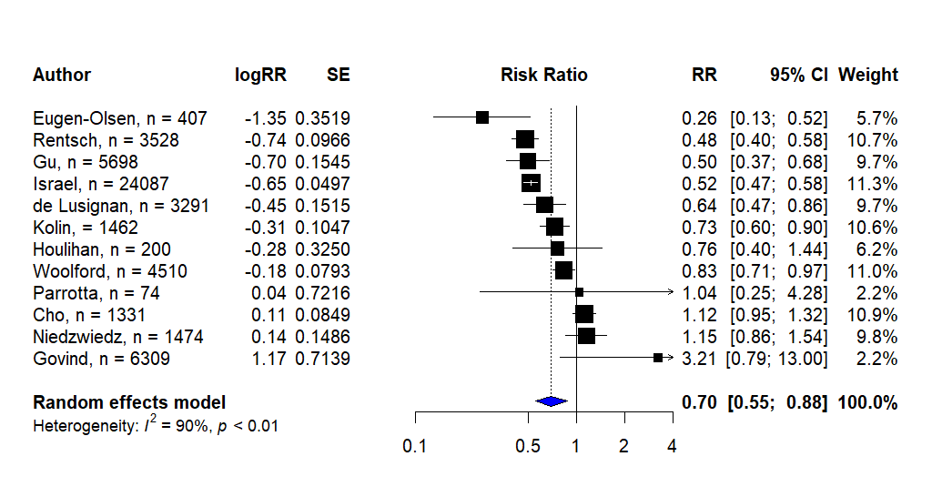

Current versus never smokers

```r
#current vs. never smokers
current_never_meta <- k %>%
  filter(smoking_status == 'current')

a<-metagen(current_never_meta$log_RR,
           current_never_meta$log_SE,
           studlab = c("Rentsch, n = 3528",
                       "Cho, n = 1331",
                       "Kolin, = 1462",
                       "de Lusignan, n = 3291",
                       "Parrotta, n = 74",
                       "Israel, n = 24087 ",
                       "Eugen-Olsen, n = 407",
                       "Houlihan, n = 200",
                       "Woolford, n = 4510",
                       "Govind, n = 6309",
                       "Gu, n = 5698",
                       "Niedzwiedz, n = 1474"),
           sm="RR",
           comb.fixed = F, comb.random = T)

png(here::here('reports', 'figure','fig_3.png'), width=1024, height=546, res=120)
forest(a,
       xlim = c(0.1, 4),
       sortvar = a$TE,
       rightlabs = c('RR', '95% CI', 'Weight'),
       leftlabs = c('Author', 'logRR', 'SE'),
       print.tau2 = F,
       col.diamond = 'blue',
       col.diamond.lines = 'black',
       col.square = 'black',
       col.square.lines = 'black',
       digits.sd = 2,
       colgap.forest.left = unit(15,"mm"))
null <- dev.off()

a
```

- **Former versus never smokers**

```
##                           RR           95%-CI %W(random)
## Rentsch, n = 3528     0.9779 [0.8196; 1.1669]        9.4
## Cho, n = 1331         1.0298 [0.8818; 1.2026]       10.2
## Kolin, = 1462         1.0439 [0.9281; 1.1741]       11.6
## de Lusignan, n = 3291 0.9674 [0.8229; 1.1373]       10.0
## Parrotta, n = 74      1.0400 [0.6174; 1.7517]        2.7
## Israel, n = 24087     0.8245 [0.7553; 0.9001]       12.6
## Eugen-Olsen, n = 407  0.8368 [0.6108; 1.1465]        5.5
## Houlihan, n = 200     1.3114 [0.9200; 1.8694]        4.7
## Woolford, n = 4510    1.0302 [0.9356; 1.1344]       12.3
## Govind, n = 6309      2.0367 [0.4783; 8.6731]        0.4
## Gu, n = 5698          0.9366 [0.8217; 1.0675]       11.1
## Niedzwiedz, n = 1474  1.4200 [1.1916; 1.6922]        9.5
##
## Number of studies combined: k = 12
##
##                          RR           95%-CI    z p-value
## Random effects model 1.0150 [0.9237; 1.1154] 0.31  0.7565
##
## Quantifying heterogeneity:
##  tau^2 = 0.0164 [0.0000; 0.0734]; tau = 0.1281 [0.0000; 0.2710];
##  I^2 = 72.3% [50.4%; 84.5%]; H = 1.90 [1.42; 2.54]
##
## Test of heterogeneity:
##      Q d.f.  p-value
##  39.69   11 < 0.0001
##
## Details on meta-analytical method:
## - Inverse variance method
## - DerSimonian-Laird estimator for tau^2
## - Jackson method for confidence interval of tau^2 and tau
```

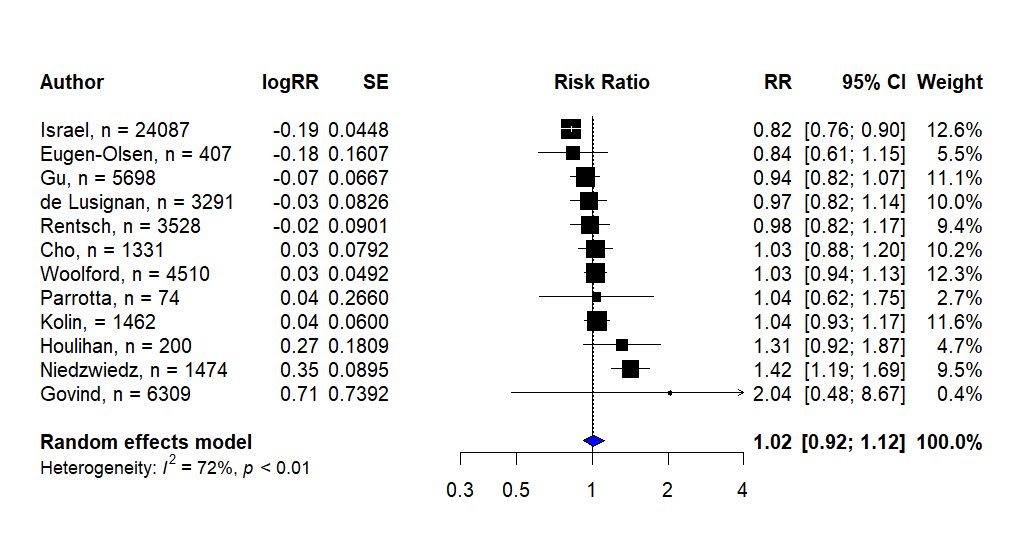

Former versus never smokers

```r
#former vs. never smokers

current_never_meta <- k %>%
  filter(smoking_status == 'former')

a<-metagen(current_never_meta$log_RR,
           current_never_meta$log_SE,
           studlab = c("Rentsch, n = 3528",
                       "Cho, n = 1331",
                       "Kolin, = 1462",
                       "de Lusignan, n = 3291",
                       "Parrotta, n = 74",
                       "Israel, n = 24087 ",
                       "Eugen-Olsen, n = 407",
                       "Houlihan, n = 200",
                       "Woolford, n = 4510",
                       "Govind, n = 6309",
                       "Gu, n = 5698",
                       "Niedzwiedz, n = 1474"),
           sm="RR", comb.fixed = F, comb.random = T)

png(here::here('reports', 'figure','fig_4.png'), width=1024, height=546, res=120)
forest(a,
       xlim = c(0.3, 4),
       sortvar = a$TE,
       rightlabs = c('RR', '95% CI', 'Weight'),
       leftlabs = c('Author', 'logRR', 'SE'),
       print.tau2 = F,
       col.diamond = 'blue',
       col.diamond.lines = 'black',
       col.square = 'black',
       col.square.lines = 'black',
       digits.sd = 2,
       colgap.forest.left = unit(15,"mm"))
null <- dev.off()

a
```

### 0.5.3 Table 3: Smoking and COVID-19 hospitalisation

```r
#Table 3
table_3_word <- table_3 %>%
  mutate(., sample = sample_with_outcome) %>%
  mutate(., community_percentage = formatC(number_community/sample*100, digits = 2, format = "f")) %>%
  mutate(., community_current_smoker_percent = formatC(community_current_smoker/number_community*100, digits = 2, format = "f")) %>%
  mutate(., community_former_smoker_percent = formatC(community_former_smoker/number_community*100, digits = 2, format = "f")) %>%
  mutate(., community_current_former_smoker_percent = formatC(community_current_former_smoker/number_community*100, digits = 2, format = "f")) %>%
  mutate(., community_never_smoker_percent = formatC(community_never_smoker/number_community*100, digits = 2, format = "f")) %>%
  mutate(., community_never_unknown_smoker_percent = formatC(community_never_unknown_smoker/number_community*100, digits = 2, format = "f")) %>%
  mutate(., community_not_stated_percent = formatC(community_not_stated/number_community*100, digits = 2, format = "f")) %>%
  mutate(., number_hospitalised_percent = formatC(number_hospitalised/sample*100, digits = 2, format = "f")) %>%
  mutate(., hospitalised_current_smoker_percent = formatC(hospitalised_current_smoker/number_hospitalised*100, digits = 2, format = "f")) %>%
  mutate(., hospitalised_former_smoker_percent = formatC(hospitalised_former_smoker/number_hospitalised*100, digits = 2, format = "f")) %>%
  mutate(., hospitalised_current_former_smoker_percent = formatC(hospitalised_current_former_smoker/number_hospitalised*100, digits = 2, format = "f")) %>%
  mutate(., hospitalised_never_smoker_percent = formatC(hospitalised_never_smoker/number_hospitalised*100, digits = 2, format = "f")) %>%
  mutate(., hospitalised_never_unknown_smoker_percent = formatC(hospitalised_never_unknown_smoker/number_hospitalised*100, digits = 2, format = "f")) %>%
  mutate(., hospitalised_not_stated_percent = formatC(hospitalised_not_stated/number_hospitalised*100, digits = 2, format = "f")) %>%
  select(lead_author, sample_with_outcome, number_community, community_percentage,
         community_current_smoker, community_current_smoker_percent, community_former_smoker,
         community_former_smoker_percent, community_current_former_smoker,
         community_current_former_smoker_percent, community_never_smoker, community_never_smoker_percent,
         community_never_unknown_smoker, community_never_unknown_smoker_percent,
         community_not_stated, community_not_stated_percent, number_hospitalised, number_hospitalised_percent,
         hospitalised_current_smoker, hospitalised_current_smoker_percent, hospitalised_former_smoker,
         hospitalised_former_smoker_percent, hospitalised_current_former_smoker, hospitalised_current_former_smoker_percent,
         hospitalised_never_smoker, hospitalised_never_smoker_percent, hospitalised_never_unknown_smoker,
         hospitalised_never_unknown_smoker_percent, hospitalised_not_stated, hospitalised_not_stated_percent) %>%
  write_rds(here::here('data_clean', 'table_3_word.rds'))

quality_table_3 <- table_3_word %>%
  left_join(., quality_rating, by = 'lead_author') %>%
  select(lead_author, overall_quality)

a <- table_3_word %>%
  filter(number_community >= 1) %>%
  mutate(Author = lead_author,
         Population = sample_with_outcome,
         Community = paste(
           paste(number_community,
                 as.integer(community_percentage), sep = " ("), "%)", sep = ""),
         C_current_smoker = paste(paste(community_current_smoker, (community_current_smoker_percent), sep = " (")
                                  , "%)", sep = ""),
         C_current_smoker = na_if(C_current_smoker, "NA ( NA%)"),
         C_former_smoker = paste(paste(community_former_smoker, (community_former_smoker_percent), sep = " (")
                                 , "%)", sep = ""),
         C_former_smoker = na_if(C_former_smoker, "NA ( NA%)"),
         C_current_former_smoker = paste(paste(community_current_former_smoker,
                                               (community_current_former_smoker_percent), sep = " (")
                                         , "%)", sep = ""),
         C_current_former_smoker = na_if(C_current_former_smoker, "NA ( NA%)"),
         C_never_smoker = paste(paste(community_never_smoker,
                                      (community_never_smoker_percent), sep = " (")
                                , "%)", sep = ""),
         C_never_smoker = na_if(C_never_smoker, "NA ( NA%)"),
         C_never_unknown_smoker = paste(paste(community_never_unknown_smoker,
                                              (community_never_unknown_smoker_percent), sep = " (")
                                        , "%)", sep = ""),
         C_never_unknown_smoker = na_if(C_never_unknown_smoker, "NA ( NA%)"),
         C_not_stated = paste(paste(community_not_stated,
                                    (community_not_stated_percent), sep = " (")
                              , "%)", sep = ""),
         C_not_stated = na_if(C_not_stated, "NA ( NA%)")) %>%
  mutate(Hospitalised = paste(
    paste(number_hospitalised,
          as.integer(number_hospitalised_percent), sep = " ("), "%)", sep = ""),
    H_current_smoker = paste(paste(hospitalised_current_smoker, (hospitalised_current_smoker_percent), sep = " (")
                             , "%)", sep = ""),
    H_current_smoker = na_if(H_current_smoker, "NA ( NA%)"),
    H_former_smoker = paste(paste(hospitalised_former_smoker, (hospitalised_former_smoker_percent), sep = " (")
                            , "%)", sep = ""),
    H_former_smoker = na_if(H_former_smoker, "NA ( NA%)"),
    H_current_former_smoker = paste(paste(hospitalised_current_former_smoker,
                                          (hospitalised_current_former_smoker_percent), sep = " (")
                                    , "%)", sep = ""),
    H_current_former_smoker = na_if(H_current_former_smoker, "NA ( NA%)"),
    H_never_smoker = paste(paste(hospitalised_never_smoker,
                                 (hospitalised_never_smoker_percent), sep = " (")
                           , "%)", sep = ""),
    H_never_smoker = na_if(H_never_smoker, "NA ( NA%)"),
    H_never_unknown_smoker = paste(paste(hospitalised_never_unknown_smoker,
                                         (hospitalised_never_unknown_smoker_percent), sep = " (")
                                   , "%)", sep = ""),
    H_never_unknown_smoker = na_if(H_never_unknown_smoker, "NA ( NA%)"),
    H_not_stated = paste(paste(hospitalised_not_stated,
                               (hospitalised_not_stated_percent), sep = " (")
                         , "%)", sep = ""),
    H_not_stated = na_if(H_not_stated, "NA ( NA%)")) %>%
  select(Author, Population, Community, C_current_smoker, C_former_smoker, C_current_former_smoker,
         C_never_smoker,C_never_unknown_smoker,C_not_stated, Hospitalised, H_current_smoker, H_former_smoker,
         H_current_former_smoker, H_never_smoker, H_never_unknown_smoker, H_not_stated)


a$Author <- to_upper_camel_case(a$Author, sep_out = ", ")
a$Author <- plyr::mapvalues(a$Author,
                               from = cleaned_names,
                               to = correct_names)

numeric_columns <- 'Population'

a <- flextable(a) %>%
    set_caption(caption = 'COVID-19 hospitalisation by smoking status') %>%
  colformat_num(col_keys = numeric_columns, digits = 0, na_str = '-', big.mark = ',') %>%
  colformat_char(na_str = '-')

a <- set_header_labels(a,
                       Population = 'Population with outcome',
                       Community = "N (%)",
                       C_current_smoker = "Current smoker (%)",
                       C_former_smoker = "Former smoker (%)",
                       C_current_former_smoker = "Current/former smoker (%)",
                       C_never_smoker = "Never smoker (%)",
                       C_never_unknown_smoker = "Never/unknown smoker (%)",
                       C_not_stated = "Not stated (%)",
                       Hospitalised = "N (%)",
                       H_current_smoker = "Current smoker (%)",
                       H_former_smoker = "Former smoker (%)",
                       H_current_former_smoker = "Current/former smoker (%)",
                       H_never_smoker = "Never smoker (%)",
                       H_never_unknown_smoker = "Never/unknown smoker (%)",
                       H_not_stated = "Not stated (%)") %>%
  add_header_row(top = TRUE, values = c("","Community", "Hospitalised" ), colwidths = c(2, 7, 7)) %>%
  theme_booktabs() %>%
  fix_border_issues() %>%
  set_table_properties(width = 1, layout = 'autofit')
a
```

COVID-19 hospitalisation by smoking status

| Author | Population with outcome | Community N (%) | Community Current smoker (%) | Community Former smoker (%) | Community Current/former smoker (%) | Community Never smoker (%) | Community Never/unknown smoker (%) | Community Not stated (%) | Hospitalised N (%) | Hospitalised Current smoker (%) | Hospitalised Former smoker (%) | Hospitalised Current/former smoker (%) | Hospitalised Never smoker (%) | Hospitalised Never/unknown smoker (%) | Hospitalised Not stated (%) |
| --- | --- | --- | --- | --- | --- | --- | --- | --- | --- | --- | --- | --- | --- | --- | --- |
| Rentsch | 554 | 269 (48%) | 69 (25.65%) | 90 (33.46%) | - | 110 (40.89%) | - | - | 285 (51%) | 90 (31.58%) | 89 (31.23%) | - | 106 (37.19%) | - | - |
| Petrilli | 4103 | 2104 (51%) | 108 (5.13%) | 250 (11.88%) | - | - | 1746 (82.98%) | - | 1999 (48%) | 104 (5.20%) | 416 (20.81%) | - | - | 1479 (73.99%) | - |
| Chow (US CDC) | 6637 | 5143 (77%) | 61 (1.19%) | 80 (1.56%) | - | - | - | 5002 (97.26%) | 1494 (22%) | 27 (1.81%) | 78 (5.22%) | - | - | - | 1389 (92.97%) |
| Argenziano | 1000 | 151 (15%) | 14 (9.27%) | 18 (11.92%) | - | 119 (78.81%) | - | - | 849 (84%) | 35 (4.12%) | 161 (18.96%) | - | 653 (76.91%) | - | - |
| Lubetzky | 54 | 15 (27%) | - | - | 4 (26.67%) | - | - | 11 (73.33%) | 39 (72%) | - | - | 8 (20.51%) | - | - | 31 (79.49%) |
| Carillo-Vega | 9946 | 3922 (39%) | 408 (10.40%) | - | - | - | - | 3514 (89.60%) | 6024 (60%) | 486 (8.07%) | - | - | - | - | 5538 (91.93%) |
| Yanover | 4353 | 4180 (96%) | 484 (11.58%) | 118 (2.82%) | - | 3578 (85.60%) | - | - | 173 (3%) | 30 (17.34%) | 11 (6.36%) | - | 132 (76.30%) | - | - |
| Hamer | 387109 | 386349 (99%) | 37333 (9.66%) | 134542 (34.82%) | - | 214474 (55.51%) | - | - | 760 (0%) | 93 (12.24%) | 313 (41.18%) | - | 354 (46.58%) | - | - |
| Heili-Frades | 4712 | 1973 (41%) | 121 (6.13%) | 222 (11.25%) | - | - | 1630 (82.62%) | 1630 (82.62%) | 2739 (58%) | 112 (4.09%) | 598 (21.83%) | - | - | 2029 (74.08%) | - |
| Freites | 123 | 69 (56%) | 1 (1.45%) | - | - | - | - | 68 (98.55%) | 54 (43%) | 3 (5.56%) | - | - | - | - | 51 (94.44%) |
| Berumen | 102875 | 18832 (18%) | - | - | 1546 (8.21%) | - | 17286 (91.79%) | - | 12690 (12%) | - | - | 1202 (9.47%) | - | 11488 (90.53%) | - |
| Gianfrancesco | 600 | 323 (53%) | - | - | 61 (18.89%) | - | - | 262 (81.11%) | 277 (46%) | - | - | 68 (24.55%) | - | - | 209 (75.45%) |
| Chaudhry | 40 | 19 (47%) | - | - | 0 (0.00%) | - | - | 19 (100.00%) | 21 (52%) | - | - | 6 (28.57%) | - | - | 15 (71.43%) |
| Giannouchos | 89756 | 58485 (65%) | 4679 (8.00%) | - | - | - | 53806 (92.00%) | - | 31271 (34%) | 2721 (8.70%) | - | - | - | 28550 (91.30%) | - |
| Wang, Oekelen | 57 | 22 (38%) | - | - | 6 (27.27%) | - | - | 16 (72.73%) | 36 (63%) | - | - | 15 (41.67%) | - | - | 20 (55.56%) |
| Miyara | 470 | 132 (28%) | 14 (10.61%) | 41 (31.06%) | - | 77 (58.33%) | - | - | 338 (71%) | 18 (5.33%) | 111 (32.84%) | - | 209 (61.83%) | - | - |
| Suleyman | 463 | 108 (23%) | - | - | 23 (21.30%) | - | - | 85 (78.70%) | 355 (76%) | - | - | 137 (38.59%) | - | - | 218 (61.41%) |
| Garassino | 196 | 48 (24%) | 10 (20.83%) | 27 (56.25%) | - | 11 (22.92%) | - | - | 152 (77%) | 38 (25.00%) | 84 (55.26%) | - | 26 (17.11%) | - | - |
| Siso-Almirall | 260 | 119 (45%) | - | - | 31 (26.05%) | - | - | 88 (73.95%) | 141 (54%) | - | - | 50 (35.46%) | - | - | 91 (64.54%) |
| Gu | 884 | 511 (57%) | 30 (5.87%) | 126 (24.66%) | - | 355 (69.47%) | - | - | 373 (42%) | 10 (2.68%) | 138 (37.00%) | - | 225 (60.32%) | - | - |
| Killerby | 531 | 311 (58%) | - | - | 37 (11.90%) | 222 (71.38%) | - | 52 (16.72%) | 220 (41%) | - | - | 54 (24.55%) | 157 (71.36%) | - | 9 (4.09%) |

```r
save_as_docx(a, path = here('data_clean', 'Table_3.docx'))
```

The number of studies reporting on hospitalisation by smoking status is: 21

#### 0.5.3.1 Smoking and hospitalisation meta-analysis

The studies included in meta-analysis are rentsch, argenziano, yanover, hamer, miyara_medrxiv, garassino, and gu.

```
##                RR           95%-CI %W(random)
## Rentsch    1.1534 [0.9517; 1.3980]       16.3
## Argenziano 0.8445 [0.7056; 1.0106]       16.5
## Yanover    1.6404 [1.1156; 2.4121]       12.6
## Hamer      1.5080 [1.2004; 1.8944]       15.7
## Miyara     0.7697 [0.5626; 1.0532]       14.0
## Garassino  1.1266 [0.8731; 1.4537]       15.2
## Gu         0.6444 [0.3732; 1.1130]        9.6
##
## Number of studies combined: k = 7
##
##                          RR           95%-CI    t p-value
## Random effects model 1.0631 [0.7852; 1.4393] 0.49  0.6387
##
## Quantifying heterogeneity:
##  tau^2 = 0.0883 [0.0182; 0.5452]; tau = 0.2972 [0.1350; 0.7384];
##  I^2 = 78.9% [56.5%; 89.7%]; H = 2.17 [1.52; 3.12]
##
## Test of heterogeneity:
##      Q d.f.  p-value
##  28.37    6 < 0.0001
##
## Details on meta-analytical method:
## - Mantel-Haenszel method
## - Sidik-Jonkman estimator for tau^2
## - Q-profile method for confidence interval of tau^2 and tau
## - Hartung-Knapp adjustment for random effects model
```

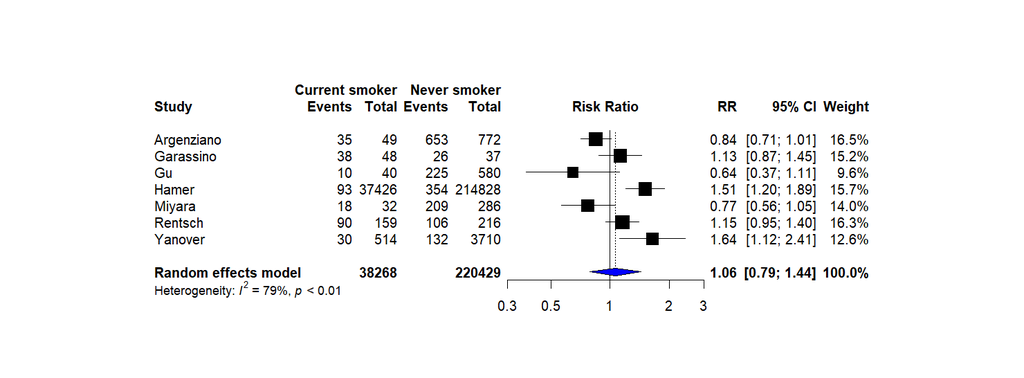

Current versus never smokers

```r
# Data --------------------------------------------------------------------
meta <- tibble('author' = table_3$lead_author,
               'community_smoker' = table_3$community_current_smoker,
               'community_never_smoker' = table_3$community_never_smoker,
               'hospitalised_smoker' = table_3$hospitalised_current_smoker,
               'hospitalised_never_smoker' = table_3$hospitalised_never_smoker,
               'community_former_smoker' = table_3$community_former_smoker,
               'hospitalised_former_smoker' = table_3$hospitalised_former_smoker) %>%
  filter(author %in% included_studies$lead_author)

meta$author <- to_upper_camel_case(meta$author, sep_out = ", ")
meta$author <- plyr::mapvalues(meta$author,
                               from = cleaned_names,
                               to = correct_names)

# Current smoker hospitalisation ------------------------------------------
event_rates_smoker <- meta %>%
  mutate(., Ee = hospitalised_smoker) %>%
  mutate(., Ne = (hospitalised_smoker+community_smoker)) %>%
  mutate(., Ec = hospitalised_never_smoker) %>%
  mutate(., Nc = (hospitalised_never_smoker+community_never_smoker)) %>%
  rename('Author' = author) %>%
  select(Author, Ee, Ne, Ec, Nc)

event_rates_smoker <- metabin(Ee,
                              Ne,
                              Ec,
                              Nc,
                              data = event_rates_smoker,
                              studlab = paste(Author),
                              comb.fixed = F,
                              comb.random = T,
                              method.tau = 'SJ',
                              hakn = T,
                              prediction = F,
                              incr = 0.1,
                              sm = 'RR')

png(here::here('reports', 'figure', 'fig_5.png'), width=1480, height=546, res=120)
current_smoker_hospitalisation <- forest(event_rates_smoker,
                                sortvar = Author,
                                xlim = c(0.3, 3),
                                rightlabs = c('RR', '95% CI', 'Weight'),
                                leftlabs = c('Author', 'logRR', 'SE'),
                                lab.e = 'Current smoker',
                                lab.c = 'Never smoker',
                                print.tau2 = F,
                                col.diamond = 'blue',
                                col.diamond.lines = 'black',
                                col.square = 'black',
                                col.square.lines = 'black',
                                digits.sd = 2)
null <- dev.off()

event_rates_smoker
```

```r
# Former smoker hospitalisation -------------------------------------------
event_rates_former <- meta %>%
  mutate(., Ee = hospitalised_former_smoker) %>%
  mutate(., Ne = (hospitalised_former_smoker+community_former_smoker)) %>%
  mutate(., Ec = hospitalised_never_smoker) %>%
  mutate(., Nc = (hospitalised_never_smoker+community_never_smoker)) %>%
  rename('Author' = author) %>%
  select(Author, Ee, Ne, Ec, Nc)

event_rates_former <- metabin(Ee,
                              Ne,
                              Ec,
                              Nc,
                              data = event_rates_former,
                              studlab = paste(Author),
                              comb.fixed = F,
                              comb.random = T,
                              method.tau = 'SJ',
                              hakn = T,
                              prediction = F,
                              incr = 0.1,
                              sm = 'RR')

a <- event_rates_former

png(here::here('reports', 'figure', 'fig_6.png'), width=1480, height=546, res=120)
former_smoker_hospitalisation <- forest(event_rates_former,
                                         sortvar = Author,
                                         xlim = c(0.3, 3),
                                         rightlabs = c('RR', '95% CI', 'Weight'),
                                         leftlabs = c('Author', 'logRR', 'SE'),
                                         lab.e = 'Former smoker',
                                         lab.c = 'Never smoker',
                                         print.tau2 = F,
                                         col.diamond = 'blue',
                                         col.diamond.lines = 'black',
                                         col.square = 'black',
                                         col.square.lines = 'black',
                                         digits.sd = 2)
null <- dev.off()
a
```

```
##                RR           95%-CI %W(random)
## Rentsch    1.0132 [0.8292; 1.2380]       14.7
## Argenziano 1.0634 [1.0039; 1.1263]       17.1
## Yanover    2.3966 [1.3292; 4.3214]        6.8
## Hamer      1.4085 [1.2100; 1.6396]       15.7
## Miyara     0.9993 [0.8867; 1.1262]       16.3
## Garassino  1.0769 [0.8517; 1.3617]       13.9
## Gu         1.3475 [1.1551; 1.5719]       15.6
##
## Number of studies combined: k = 7
##
##                          RR           95%-CI    t p-value
## Random effects model 1.1997 [0.9548; 1.5075] 1.95  0.0989
##
## Quantifying heterogeneity:
##  tau^2 = 0.0580 [0.0069; 0.4097]; tau = 0.2407 [0.0828; 0.6400];
##  I^2 = 78.6% [55.8%; 89.6%]; H = 2.16 [1.50; 3.10]
##
## Test of heterogeneity:
##      Q d.f.  p-value
##  28.00    6 < 0.0001
##
## Details on meta-analytical method:
## - Mantel-Haenszel method
## - Sidik-Jonkman estimator for tau^2
## - Q-profile method for confidence interval of tau^2 and tau
## - Hartung-Knapp adjustment for random effects model
```

```r
running_meta_count <- running_meta_count %>%
  full_join(., meta %>%
  rename("study" = author), by = "study") %>%
  select(study)
```

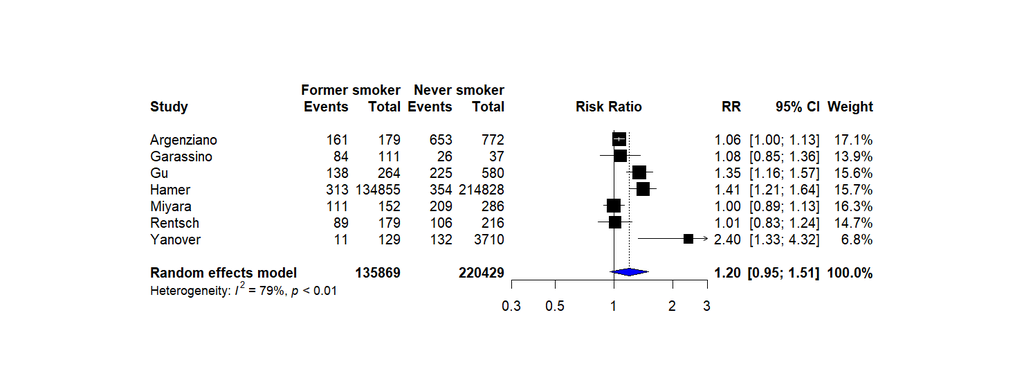

Former versus never smokers

### 0.5.4 Table 4: Smoking and COVID-19 disease severity

```r
#Table 4
table_4_word <- table_4 %>%
  mutate(., sample = sample_with_severity) %>%
  mutate(., non_severe_disease_percentage = formatC(non_severe_disease/sample*100, digits = 2, format = "f")) %>%
  mutate(., non_severe_current_smoker_percent = formatC(non_severe_current_smoker/non_severe_disease*100, digits = 2, format = "f")) %>%
  mutate(., non_severe_former_smoker_percent = formatC(non_severe_former_smoker/non_severe_disease*100, digits = 2, format = "f")) %>%
  mutate(., non_severe_current_former_smoker_percent = formatC(non_severe_current_former_smoker/non_severe_disease*100, digits = 2, format = "f")) %>%
  mutate(., non_severe_never_smoker_percent = formatC(non_severe_never_smoker/non_severe_disease*100, digits = 2, format = "f")) %>%
  mutate(., non_severe_never_unknown_smoker_percent = formatC(non_severe_never_unknown_smoker/non_severe_disease*100, digits = 2, format = "f")) %>%
  mutate(., non_severe_not_stated_percent = formatC(non_severe_not_stated/non_severe_disease*100, digits = 2, format = "f")) %>%
  mutate(., severe_disease_number_percent = formatC(severe_disease_number/sample*100, digits = 2, format = "f")) %>%
  mutate(., severe_disease_current_smoker_percent = formatC(severe_disease_current_smoker/severe_disease_number*100, digits = 2, format = "f")) %>%
  mutate(., severe_disease_former_smoker_percent = formatC(severe_disease_former_smoker/severe_disease_number*100, digits = 2, format = "f")) %>%
  mutate(., severe_disease_current_former_smoker_percent = formatC(severe_disease_current_former_smoker/severe_disease_number*100, digits = 2, format = "f")) %>%
  mutate(., severe_disease_never_smoker_percent = formatC(severe_disease_never_smoker/severe_disease_number*100, digits = 2, format = "f")) %>%
  mutate(., severe_disease_never_unknown_percent = formatC(severe_disease_never_unknown/severe_disease_number*100, digits = 2, format = "f")) %>%
  mutate(., severe_disease_not_stated_percent = formatC(severe_disease_not_stated/severe_disease_number*100, digits = 2, format = "f")) %>%
  select(lead_author, sample, non_severe_disease, non_severe_disease_percentage, non_severe_current_smoker,
         non_severe_current_smoker_percent, non_severe_former_smoker, non_severe_former_smoker_percent,
         non_severe_current_former_smoker, non_severe_current_former_smoker_percent, non_severe_never_smoker,
         non_severe_never_smoker_percent, non_severe_never_unknown_smoker, non_severe_never_unknown_smoker_percent,
         non_severe_not_stated, non_severe_not_stated_percent, severe_disease_number, severe_disease_number_percent,
         severe_disease_current_smoker, severe_disease_current_smoker_percent,
         severe_disease_former_smoker, severe_disease_former_smoker_percent, severe_disease_current_former_smoker,
         severe_disease_current_former_smoker_percent, severe_disease_never_smoker, severe_disease_never_smoker_percent,
         severe_disease_never_unknown, severe_disease_never_unknown_percent, severe_disease_not_stated,
         severe_disease_not_stated_percent) %>%
  write_rds(here::here('data_clean', 'table_4_word.rds'))

quality_table_4 <- table_4_word %>%
  left_join(., quality_rating, by = 'lead_author') %>%
  select(lead_author, overall_quality)

a <- table_4_word %>%
  filter(non_severe_disease >= 1) %>%
  mutate(Author = lead_author,
         Population = sample,
         non_severe_disease = paste(
           paste(non_severe_disease,
                 as.integer(non_severe_disease_percentage), sep = " ("), "%)", sep = ""),
         ns_current_smoker = paste(paste(non_severe_current_smoker, (non_severe_current_smoker_percent), sep = " (")
                                  , "%)", sep = ""),
         ns_current_smoker = na_if(ns_current_smoker, "NA ( NA%)"),
         ns_former_smoker = paste(paste(non_severe_former_smoker, (non_severe_former_smoker_percent), sep = " (")
                                 , "%)", sep = ""),
         ns_former_smoker = na_if(ns_former_smoker, "NA ( NA%)"),
         ns_current_former_smoker = paste(paste(non_severe_current_former_smoker,
                                               (non_severe_current_former_smoker_percent), sep = " (")
                                         , "%)", sep = ""),
         ns_current_former_smoker = na_if(ns_current_former_smoker, "NA ( NA%)"),
         ns_never_smoker = paste(paste(non_severe_never_smoker,
                                      (non_severe_never_smoker_percent), sep = " (")
                                , "%)", sep = ""),
         ns_never_smoker = na_if(ns_never_smoker, "NA ( NA%)"),
         ns_never_unknown_smoker = paste(paste(non_severe_never_unknown_smoker,
                                              (non_severe_never_unknown_smoker_percent), sep = " (")
                                        , "%)", sep = ""),
         ns_never_unknown_smoker = na_if(ns_never_unknown_smoker, "NA ( NA%)"),
         ns_not_stated = paste(paste(non_severe_not_stated,
                                    (non_severe_not_stated_percent), sep = " (")
                              , "%)", sep = ""),
         ns_not_stated = na_if(ns_not_stated, "NA ( NA%)"),
         ) %>%
  mutate(severe_disease = paste(
    paste(severe_disease_number,
          as.integer(severe_disease_number_percent), sep = " ("), "%)", sep = ""),
    s_current_smoker = paste(paste(severe_disease_current_smoker, (severe_disease_current_smoker_percent), sep = " (")
                             , "%)", sep = ""),
    s_current_smoker = na_if(s_current_smoker, "NA ( NA%)"),
    s_former_smoker = paste(paste(severe_disease_former_smoker, (severe_disease_former_smoker_percent), sep = " (")
                            , "%)", sep = ""),
    s_former_smoker = na_if(s_former_smoker, "NA ( NA%)"),
    s_current_former_smoker = paste(paste(severe_disease_current_former_smoker,
                                          (severe_disease_current_former_smoker_percent), sep = " (")
                                    , "%)", sep = ""),
    s_current_former_smoker = na_if(s_current_former_smoker, "NA ( NA%)"),
    s_never_smoker = paste(paste(severe_disease_never_smoker,
                                 (severe_disease_never_smoker_percent), sep = " (")
                           , "%)", sep = ""),
    s_never_smoker = na_if(s_never_smoker, "NA ( NA%)"),
    s_never_unknown_smoker = paste(paste(severe_disease_never_unknown,
                                         (severe_disease_never_unknown_percent), sep = " (")
                                   , "%)", sep = ""),
    s_never_unknown_smoker = na_if(s_never_unknown_smoker, "NA ( NA%)"),
    s_not_stated = paste(paste(severe_disease_not_stated,
                                 (severe_disease_not_stated_percent), sep = " (")
                           , "%)", sep = ""),
    s_not_stated = na_if(s_not_stated, "NA ( NA%)")) %>%
  select(Author, Population, non_severe_disease, ns_current_smoker, ns_former_smoker,
         ns_current_former_smoker, ns_never_smoker, ns_never_unknown_smoker, ns_not_stated,
         severe_disease, s_current_smoker, s_former_smoker, s_current_former_smoker, s_never_smoker, s_never_unknown_smoker,
         s_not_stated)


a$Author <- to_upper_camel_case(a$Author, sep_out = ", ")
a$Author <- plyr::mapvalues(a$Author,
                               from = cleaned_names,
                               to = correct_names)
numeric_columns <- 'Population'

a <- flextable(a) %>%
    set_caption(caption = 'COVID-19 severity by smoking status') %>%
  colformat_num(col_keys = numeric_columns, digits = 0, na_str = '-', big.mark = ',') %>%
  colformat_char(na_str = '-')

a <- set_header_labels(a,
                       Population = "Population with severity",
                       non_severe_disease = "N (%)",
                       ns_current_smoker = "Current smoker (%)",
                       ns_former_smoker = "Former smoker (%)",
                       ns_current_former_smoker = "Current/former smoker (%)",
                       ns_never_unknown_smoker = "Never/unknown smoker (%)",
                       ns_never_smoker = "Never smoker (%)",
                       ns_not_stated = "Not stated (%)",
                       severe_disease = "N (%)",
                       s_current_smoker = "Current smoker (%)",
                       s_former_smoker = "Former smoker (%)",
                       s_current_former_smoker = "Current/former smoker (%)",
                       s_never_unknown_smoker = "Never/unknown smoker (%)",
                       s_never_smoker = "Never smoker (%)",
                       s_not_stated = "Not stated (%)") %>%
  add_header_row(top = TRUE, values = c("","Non severe disease", "Severe disease" ), colwidths = c(2, 7, 7)) %>%
  theme_booktabs() %>%
  fix_border_issues() %>%
  set_table_properties(width = 1, layout = 'autofit')
a
```

COVID-19 severity by smoking status

| Author | Population with severity | Non severe disease N (%) | Non severe disease Current smoker (%) | Non severe disease Former smoker (%) | Non severe disease Current/former smoker (%) | Non severe disease Never smoker (%) | Non severe disease Never/unknown smoker (%) | Non severe disease Not stated (%) | Severe disease N (%) | Severe disease Current smoker (%) | Severe disease Former smoker (%) | Severe disease Current/former smoker (%) | Severe disease Never smoker (%) | Severe disease Never/unknown smoker (%) | Severe disease Not stated (%) |
| --- | --- | --- | --- | --- | --- | --- | --- | --- | --- | --- | --- | --- | --- | --- | --- |
| Guan, Ni | 1085 | 913 (84%) | 108 (11.83%) | 12 (1.31%) | - | 793 (86.86%) | - | - | 172 (15%) | 29 (16.86%) | 9 (5.23%) | - | 134 (77.91%) | - | - |
| Zhang, Dong | 9 | 3 (33%) | 0 (0.00%) | 3 (100.00%) | - | 0 (0.00%) | - | - | 6 (66%) | 2 (33.33%) | 4 (66.67%) | - | 0 (0.00%) | - | - |
| Wan | 9 | 8 (88%) | 8 (100.00%) | 0 (0.00%) | - | 0 (0.00%) | - | - | 1 (11%) | 1 (100.00%) | 0 (0.00%) | - | 0 (0.00%) | - | - |
| Huang, Wang | 3 | 3 (100%) | 3 (100.00%) | 0 (0.00%) | - | 0 (0.00%) | - | - | 0 (0%) | 0 (NaN%) | 0 (NaN%) | - | 0 (NaN%) | - | - |
| Rentsch | 285 | 168 (58%) | 47 (27.98%) | 53 (31.55%) | - | 68 (40.48%) | - | - | 117 (41%) | 43 (36.75%) | 36 (30.77%) | - | 38 (32.48%) | - | - |
| Hu | 323 | 151 (46%) | - | - | 12 (7.95%) | - | 139 (92.05%) | - | 172 (53%) | - | - | 26 (15.12%) | - | 146 (84.88%) | - |
| Wang, Pan | 125 | 100 (80%) | - | - | 9 (9.00%) | - | 91 (91.00%) | - | 25 (20%) | - | - | 7 (28.00%) | - | 18 (72.00%) | - |
| Petrilli | 1278 | 932 (72%) | 62 (6.65%) | 175 (18.78%) | - | - | 391 (41.95%) | - | 650 (50%) | 28 (4.31%) | 145 (22.31%) | - | - | 477 (73.38%) | - |
| Kim | 27 | 21 (77%) | 3 (14.29%) | - | - | - | 18 (85.71%) | - | 6 (22%) | 2 (33.33%) | 0 (0.00%) | - | - | 4 (66.67%) | - |
| Shi, Yu | 474 | 425 (89%) | - | - | 34 (8.00%) | - | 391 (92.00%) | - | 49 (10%) | - | - | 6 (12.24%) | - | 43 (87.76%) | - |
| Liao, Feng | 148 | 92 (62%) | - | - | 5 (5.43%) | - | - | 87 (94.57%) | 56 (37%) | 3 (5.36%) | - | - | - | - | 53 (94.64%) |
| Shi, Ren | 134 | 88 (65%) | - | - | 8 (9.09%) | - | - | 80 (90.91%) | 46 (34%) | - | - | 6 (13.04%) | - | - | 40 (86.96%) |
| Hadjadj | 50 | 15 (30%) | 1 (6.67%) | 2 (13.33%) | - | 12 (80.00%) | - | - | 35 (70%) | 0 (0.00%) | 7 (20.00%) | - | 28 (80.00%) | - | - |
| Zheng, Xiong | 73 | 43 (58%) | - | - | 6 (13.95%) | 37 (86.05%) | - | - | 30 (41%) | - | - | 2 (6.67%) | 28 (93.33%) | - | - |
| de la Rica | 48 | 26 (54%) | - | - | 6 (23.08%) | - | - | 20 (76.92%) | 20 (41%) | - | - | 4 (20.00%) | - | - | 16 (80.00%) |
| Yin, Yang | 106 | 47 (44%) | - | - | 6 (12.77%) | - | - | 41 (87.23%) | 59 (55%) | - | - | 12 (20.34%) | - | - | 47 (79.66%) |
| Allenbach | 147 | 100 (68%) | - | - | 9 (9.00%) | - | - | 91 (91.00%) | 47 (31%) | - | - | 0 (0.00%) | - | - | 47 (100.00%) |
| Goyal | 393 | 263 (66%) | 14 (5.32%) | - | - | - | - | 249 (94.68%) | 130 (33%) | 6 (4.62%) | - | - | - | - | 124 (95.38%) |
| Feng | 454 | 333 (73%) | 27 (8.11%) | - | - | - | - | 306 (91.89%) | 121 (26%) | 17 (14.05%) | - | - | - | - | 104 (85.95%) |
| Yao | 108 | 83 (76%) | 1 (1.20%) | - | - | - | - | 82 (98.80%) | 25 (23%) | 3 (12.00%) | - | - | - | - | 22 (88.00%) |
| Sami | 490 | 400 (81%) | 53 (13.25%) | - | - | - | - | 347 (86.75%) | 90 (18%) | 16 (17.78%) | - | - | - | - | 74 (82.22%) |
| Regina | 200 | 163 (81%) | 9 (5.52%) | - | - | - | - | 154 (94.48%) | 37 (18%) | 0 (0.00%) | - | - | - | - | 37 (100.00%) |
| Feuth | 28 | 21 (75%) | 1 (4.76%) | 7 (33.33%) | - | 13 (61.90%) | - | - | 7 (25%) | 2 (28.57%) | 1 (14.29%) | - | 4 (57.14%) | - | - |
| Mejia-Vilet | 329 | 214 (65%) | - | - | 13 (6.07%) | - | - | 201 (93.93%) | 115 (34%) | - | - | 10 (8.70%) | - | - | 105 (91.30%) |
| Chen, Jiang | 135 | 54 (40%) | - | - | 4 (7.41%) | - | - | 50 (92.59%) | 81 (60%) | - | - | 9 (11.11%) | - | - | 72 (88.89%) |
| Vaquero-Roncero | 146 | 75 (51%) | - | - | 4 (5.33%) | - | - | 71 (94.67%) | 71 (48%) | - | - | 6 (8.45%) | - | - | 65 (91.55%) |
| Kim, Garg | 2490 | 1692 (67%) | 112 (6.62%) | 395 (23.35%) | - | - | 1185 (70.04%) | - | 798 (32%) | 38 (4.76%) | 247 (30.95%) | - | - | 512 (64.16%) | - |
| Wu | 174 | 92 (52%) | - | - | 47 (51.09%) | - | 45 (48.91%) | - | 82 (47%) | 11 (13.41%) | - | - | - | 71 (86.59%) | - |
| Chaudhry | 40 | 34 (85%) | - | - | 5 (14.71%) | - | - | 29 (85.29%) | 6 (15%) | - | - | 1 (16.67%) | - | - | 5 (83.33%) |
| Patel | 104 | 67 (64%) | 25 (37.31%) | - | - | - | 36 (53.73%) | 6 (8.96%) | 37 (35%) | 18 (48.65%) | - | - | - | 15 (40.54%) | 4 (10.81%) |
| Garibaldi | 832 | 532 (63%) | 25 (4.70%) | 107 (20.11%) | - | - | - | 400 (75.19%) | 300 (36%) | 21 (7.00%) | 81 (27.00%) | - | - | - | 198 (66.00%) |
| Kuderer | 928 | 686 (73%) | 35 (5.10%) | 210 (30.61%) | - | 370 (53.94%) | - | 29 (4.23%) | 242 (26%) | 8 (3.31%) | 116 (47.93%) | - | 99 (40.91%) | 15 (6.20%) | 4 (1.65%) |
| Romao | 14 | 14 (100%) | - | - | 4 (28.57%) | - | - | 10 (71.43%) | 0 (0%) | - | - | - | - | - | - |
| Giannouchos | 89756 | 78050 (86%) | 6322 (8.10%) | - | - | - | 71728 (91.90%) | - | 11706 (13%) | 1089 (9.30%) | - | - | - | 10617 (90.70%) | - |
| Cen | 1007 | 720 (71%) | - | - | 70 (9.72%) | - | - | 650 (90.28%) | 287 (28%) | - | - | 18 (6.27%) | - | - | 269 (93.73%) |
| Maraschini | 132 | 89 (67%) | - | 11 (12.36%) | - | 78 (87.64%) | - | - | 43 (32%) | - | 3 (6.98%) | - | 40 (93.02%) | - | - |
| Russell, Moss | 156 | 128 (82%) | 9 (7.03%) | 31 (24.22%) | - | 51 (39.84%) | - | 37 (28.91%) | 28 (17%) | 2 (7.14%) | 8 (28.57%) | - | 8 (28.57%) | - | 10 (35.71%) |
| Siso-Almirall | 260 | 212 (81%) | - | - | 60 (28.30%) | - | - | 152 (71.70%) | 48 (18%) | - | - | 21 (43.75%) | - | - | 27 (56.25%) |
| Gu | 884 | 511 (57%) | 30 (5.87%) | 126 (24.66%) | - | 355 (69.47%) | - | - | 134 (15%) | 3 (2.24%) | 61 (45.52%) | - | 70 (52.24%) | - | - |

```r
save_as_docx(a, path = here('data_clean', 'Table_4.docx'))
```

The number of studies reporting on hospitalisation by smoking status is: 40

#### 0.5.4.1 Smoking and severity meta-analysis

The studies included in meta-analysis are guan_ni, rentsch, hadjadj, feuth, kuderer, and gu.

```
##              RR            95%-CI %W(fixed)
## Guan, Ni 1.4644 [1.0226;  2.0970]      34.9
## Rentsch  1.3327 [0.9544;  1.8611]      35.3
## Hadjadj  0.1297 [0.0004; 47.9753]       1.6
## Feuth    2.8333 [0.8772;  9.1514]       1.2
## Kuderer  0.8814 [0.4605;  1.6870]      16.8
## Gu       0.5519 [0.1837;  1.6581]      10.2
##
## Number of studies combined: k = 6
##
##                        RR           95%-CI    z p-value
## Fixed effect model 1.2214 [0.9775; 1.5261] 1.76  0.0784
##
## Quantifying heterogeneity:
##  tau^2 = 0.3164 [0.0000; 3.0660]; tau = 0.5625 [0.0000; 1.7510];
##  I^2 = 22.2% [0.0%; 66.5%]; H = 1.13 [1.00; 1.73]
##
## Test of heterogeneity:
##     Q d.f. p-value
##  6.43    5  0.2666
##
## Details on meta-analytical method:
## - Mantel-Haenszel method
## - Sidik-Jonkman estimator for tau^2
## - Q-profile method for confidence interval of tau^2 and tau
## - Continuity correction of 0.1 in studies with zero cell frequencies
```

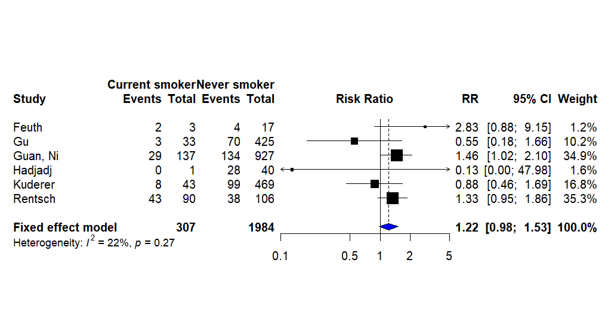

Current versus never smokers

```r
# Data --------------------------------------------------------------------
meta <- tibble('author' = table_4$lead_author,
               'non_severe_smoker' = table_4$non_severe_current_smoker,
               'non_severe_never_smoker' = table_4$non_severe_never_smoker,
               'severe_smoker' = table_4$severe_disease_current_smoker,
               'severe_never_smoker' = table_4$severe_disease_never_smoker,
               'non_severe_former_smoker' = table_4$non_severe_former_smoker,
               'severe_former_smoker' = table_4$severe_disease_former_smoker) %>%
  filter(author %in% included_studies$lead_author)

meta$author <- to_upper_camel_case(meta$author, sep_out = ", ")
meta$author <- plyr::mapvalues(meta$author,
                               from = cleaned_names,
                               to = correct_names)

# Current smoker severity ------------------------------------------
event_rates_smoker <- meta %>%
  mutate(., Ee = severe_smoker) %>%
  mutate(., Ne = (severe_smoker+non_severe_smoker)) %>%
  mutate(., Ec = severe_never_smoker) %>%
  mutate(., Nc = (severe_never_smoker+non_severe_never_smoker)) %>%
  rename('Author' = author) %>%
  select(Author, Ee, Ne, Ec, Nc)

event_rates_smoker <- metabin(Ee,
                              Ne,
                              Ec,
                              Nc,
                              data = event_rates_smoker,
                              studlab = paste(Author),
                              comb.fixed = T,
                              comb.random = F,
                              method.tau = 'SJ',
                              hakn = F,
                              prediction = F,
                              incr = 0.1,
                              sm = 'RR')
png(here::here('reports', 'figure', 'fig_7.png'), width=1024, height=546, res=120)
current_smoker_severity <- forest(event_rates_smoker,
                                         sortvar = Author,
                                         xlim = c(0.1, 5),
                                         rightlabs = c('RR', '95% CI', 'Weight'),
                                         leftlabs = c('Author', 'logRR', 'SE'),
                                         lab.e = 'Current smoker',
                                         lab.c = 'Never smoker',
                                         print.tau2 = F,
                                         col.diamond = 'blue',
                                         col.diamond.lines = 'black',
                                         col.square = 'black',
                                         col.square.lines = 'black',
                                         digits.sd = 2)
null <- dev.off()

event_rates_smoker
```

```r
# Former smoker hospitalisation -------------------------------------------
event_rates_former <- meta %>%
  mutate(., Ee = severe_former_smoker) %>%
  mutate(., Ne = (severe_former_smoker+non_severe_former_smoker)) %>%
  mutate(., Ec = severe_never_smoker) %>%
  mutate(., Nc = (severe_never_smoker+non_severe_never_smoker)) %>%
  rename('Author' = author) %>%
  select(Author, Ee, Ne, Ec, Nc)

event_rates_former <- metabin(Ee,
                              Ne,
                              Ec,
                              Nc,
                              data = event_rates_former,
                              studlab = paste(Author),
                              comb.fixed = F,
                              comb.random = T,
                              method.tau = 'SJ',
                              hakn = F,
                              prediction = F,
                              incr = 0.1,
                              sm = 'RR')

png(here::here('reports', 'figure', 'fig_8.png'), width=1024, height=546, res=120)
former_smoker_severity <- forest(event_rates_former,
                                        sortvar = Author,
                                        xlim = c(0.2, 10),
                                        rightlabs = c('RR', '95% CI', 'Weight'),
                                        leftlabs = c('Author', 'logRR', 'SE'),
                                        lab.e = 'Former smoker',
                                        lab.c = 'Never smoker',
                                        print.tau2 = F,
                                        col.diamond = 'blue',
                                        col.diamond.lines = 'black',
                                        col.square = 'black',
                                        col.square.lines = 'black',
                                        digits.sd = 2)
null <- dev.off()

event_rates_former
```

```
##              RR           95%-CI %W(random)
## Guan, Ni 2.9648 [1.7660; 4.9774]       16.5
## Rentsch  1.1283 [0.7885; 1.6146]       19.5
## Hadjadj  1.1111 [0.7419; 1.6640]       18.6
## Feuth    0.5312 [0.0702; 4.0199]        3.2
## Kuderer  1.6857 [1.3421; 2.1172]       21.6
## Gu       1.9805 [1.4715; 2.6657]       20.6
##
## Number of studies combined: k = 6
##
##                          RR           95%-CI    z p-value
## Random effects model 1.5775 [1.0707; 2.3242] 2.31  0.0211
##
## Quantifying heterogeneity:
##  tau^2 = 0.1671 [0.0095; 1.6211]; tau = 0.4088 [0.0976; 1.2732];
##  I^2 = 67.8% [23.7%; 86.4%]; H = 1.76 [1.14; 2.71]
##
## Test of heterogeneity:
##      Q d.f. p-value
##  15.53    5  0.0083
##
## Details on meta-analytical method:
## - Mantel-Haenszel method
## - Sidik-Jonkman estimator for tau^2
## - Q-profile method for confidence interval of tau^2 and tau
```

```r
running_meta_count <- running_meta_count %>%
  full_join(., meta %>%
  rename("study" = author), by = "study") %>%
  select(study)
```

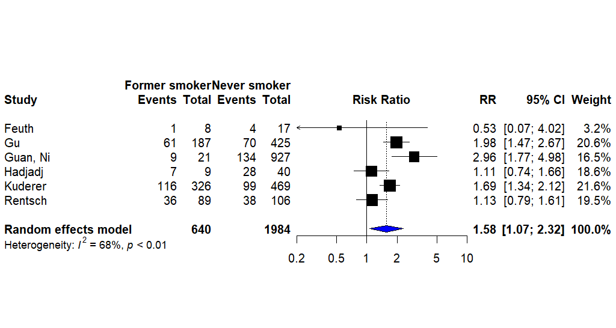

Former versus never smokers

### 0.5.5 Table 5: Smoking and COVID-19 mortality

```r
#Table 5
table_5_word <- table_5 %>%
  mutate(., sample = sample_with_deaths) %>%
  mutate(., deaths_percentage = formatC(deaths/sample*100, digits = 2, format = "f")) %>%
  mutate(., death_current_smokers_percent = formatC(death_current_smokers/deaths*100, digits = 2, format = "f")) %>%
  mutate(., death_former_smokers_percent = formatC(death_former_smokers/deaths*100, digits = 2, format = "f")) %>%
  mutate(., death_current_former_smokers_percent = formatC(death_current_former_smokers/deaths*100, digits = 2, format = "f")) %>%
  mutate(., death_never_smokers_percent = formatC(death_never_smokers/deaths*100, digits = 2, format = "f")) %>%
  mutate(., death_never_unknown_smokers_percent = formatC(death_never_unknown_smokers/deaths*100, digits = 2, format = "f")) %>%
  mutate(., death_not_stated_percent = formatC(death_not_stated/deaths*100, digits = 2, format = "f")) %>%
  mutate(., recovered_percentage = formatC(recovered/sample*100, digits = 2, format = "f")) %>%
  mutate(., recovered_current_smokers_percent = formatC(recovered_current_smoking/recovered*100, digits = 2, format = "f")) %>%
  mutate(., recovered_former_smokers_percent = formatC(recovered_former_smoker/recovered*100, digits = 2, format = "f")) %>%
  mutate(., recovered_current_former_smokers_percent = formatC(recovered_current_former_smokers/recovered*100, digits = 2, format = "f")) %>%
  mutate(., recovered_never_smokers_percent = formatC(recovered_never_smoker/recovered*100, digits = 2, format = "f")) %>%
  mutate(., recovered_never_unknown_smokers_percent = formatC(recovered_never_unknown_smoker/recovered*100, digits = 2, format = "f")) %>%
  mutate(., recovered_not_stated_percent = formatC(recovered_not_stated/recovered*100, digits = 2, format = "f")) %>%
  select(lead_author, sample, recovered, recovered_percentage, recovered_current_smoking, recovered_current_smokers_percent,
         recovered_former_smoker, recovered_former_smokers_percent, recovered_current_former_smokers,
         recovered_current_former_smokers_percent, recovered_never_smoker, recovered_never_smokers_percent,
         recovered_never_unknown_smoker, recovered_never_unknown_smokers_percent, recovered_not_stated,
         recovered_not_stated_percent,
         deaths, deaths_percentage, death_current_smokers, death_current_smokers_percent,
         death_former_smokers, death_former_smokers_percent, death_current_former_smokers,
         death_current_former_smokers_percent, death_never_smokers, death_never_smokers_percent,
         death_never_unknown_smokers, death_never_unknown_smokers_percent, death_not_stated, death_not_stated_percent) %>%
  write_rds(here::here('data_clean', 'table_5_word.rds'))

quality_table_5 <- table_5_word %>%
  left_join(., quality_rating, by = 'lead_author') %>%
  select(lead_author, overall_quality)

a <- table_5_word %>%
  filter(recovered >= 1) %>%
  mutate(Author = lead_author,
         Population = sample,
         recovered = paste(
           paste(recovered,
                 as.integer(recovered_percentage), sep = " ("), "%)", sep = ""),
         recovered_current_smoker = paste(paste(recovered_current_smoking,
                                                 (recovered_current_smokers_percent), sep = " (")
                                  , "%)", sep = ""),
         recovered_current_smoker = na_if(recovered_current_smoker, "NA ( NA%)"),
         recovered_former_smoker = paste(paste(recovered_former_smoker,
                                               (recovered_former_smokers_percent), sep = " (")
                                 , "%)", sep = ""),
         recovered_former_smoker = na_if(recovered_former_smoker, "NA ( NA%)"),
         recovered_current_former_smoker = paste(paste(recovered_current_former_smokers,
                                               (recovered_current_former_smokers_percent), sep = " (")
                                         , "%)", sep = ""),
         recovered_current_former_smoker = na_if(recovered_current_former_smoker, "NA ( NA%)"),
         recovered_never_smoker = paste(paste(recovered_never_smoker,
                                      (recovered_never_smokers_percent), sep = " (")
                                , "%)", sep = ""),
         recovered_never_smoker = na_if(recovered_never_smoker, "NA ( NA%)"),
         recovered_never_unknown_smoker = paste(paste(recovered_never_unknown_smoker,
                                              (recovered_never_unknown_smokers_percent), sep = " (")
                                        , "%)", sep = ""),
         recovered_never_unknown_smoker = na_if(recovered_never_unknown_smoker, "NA ( NA%)"),
         recovered_not_stated = paste(paste(recovered_not_stated,
                                    (recovered_not_stated_percent), sep = " (")
                              , "%)", sep = ""),
         recovered_not_stated = na_if(recovered_not_stated, "NA ( NA%)")) %>%
  mutate(deaths = paste(
           paste(deaths,
                 as.integer(deaths_percentage), sep = " ("), "%)", sep = ""),
         death_current_smoker = paste(paste(death_current_smokers,
                                                 (death_current_smokers_percent), sep = " (")
                                  , "%)", sep = ""),
         death_current_smoker = na_if(death_current_smoker, "NA ( NA%)"),
         death_former_smoker = paste(paste(death_former_smokers,
                                               (death_former_smokers_percent), sep = " (")
                                 , "%)", sep = ""),
         death_former_smoker = na_if(death_former_smoker, "NA ( NA%)"),
         death_current_former_smoker = paste(paste(death_current_former_smokers,
                                               (death_current_former_smokers_percent), sep = " (")
                                         , "%)", sep = ""),
         death_current_former_smoker = na_if(death_current_former_smoker, "NA ( NA%)"),
         death_never_smoker = paste(paste(death_never_smokers,
                                      (death_never_smokers_percent), sep = " (")
                                , "%)", sep = ""),
         death_never_smoker = na_if(death_never_smoker, "NA ( NA%)"),
         death_never_unknown_smoker = paste(paste(death_never_unknown_smokers,
                                              (death_never_unknown_smokers_percent), sep = " (")
                                        , "%)", sep = ""),
         death_never_unknown_smoker = na_if(death_never_unknown_smoker, "NA ( NA%)"),
         death_not_stated = paste(paste(death_not_stated,
                                    (death_not_stated_percent), sep = " (")
                              , "%)", sep = ""),
         death_not_stated = na_if(death_not_stated, "NA ( NA%)")) %>%
  select(Author, Population, recovered, recovered_current_smoker, recovered_former_smoker, recovered_current_former_smoker,
         recovered_never_smoker, recovered_never_unknown_smoker, recovered_not_stated, deaths, death_current_smoker,
         death_former_smoker, death_current_former_smoker, death_never_smoker, death_never_unknown_smoker,
         death_not_stated)


a$Author <- to_upper_camel_case(a$Author, sep_out = ", ")
a$Author <- plyr::mapvalues(a$Author,
                               from = cleaned_names,
                               to = correct_names)

numeric_columns <- 'Population'

a <- flextable(a) %>%
    set_caption(caption = 'COVID-19 mortality by smoking status') %>%
  colformat_num(col_keys = numeric_columns, digits = 0, na_str = '-', big.mark = ',') %>%
  colformat_char(na_str = '-')

a <- set_header_labels(a,
                       Population = "Population with mortality",
                       recovered = "N (%)",
                       recovered_current_smoker = "Current smoker (%)",
                       recovered_former_smoker = "Former smoker (%)",
                       recovered_current_former_smoker = "Current/former smoker (%)",
                       recovered_never_unknown_smoker = "Never/unknown smoker (%)",
                       recovered_never_smoker = "Never smoker (%)",
                       recovered_not_stated = "Not stated (%)",
                       deaths = "N (%)",
                       death_current_smoker = "Current smoker (%)",
                       death_former_smoker = "Former smoker (%)",
                       death_current_former_smoker = "Current/former smoker (%)",
                       death_never_unknown_smoker = "Never/unknown smoker (%)",
                       death_never_smoker = "Never smoker (%)",
                       death_not_stated = "Not stated (%)") %>%
  add_header_row(top = TRUE, values = c("","Recovered", "Died" ), colwidths = c(2, 7, 7)) %>%
  theme_booktabs() %>%
  fix_border_issues() %>%
  set_table_properties(width = 1, layout = 'autofit')
a
```

COVID-19 mortality by smoking status

| Author | Population with mortality | Recovered N (%) | Recovered Current smoker (%) | Recovered Former smoker (%) | Recovered Current/former smoker (%) | Recovered Never smoker (%) | Recovered Never/unknown smoker (%) | Recovered Not stated (%) | Died N (%) | Died Current smoker (%) | Died Former smoker (%) | Died Current/former smoker (%) | Died Never smoker (%) | Died Never/unknown smoker (%) | Died Not stated (%) |
| --- | --- | --- | --- | --- | --- | --- | --- | --- | --- | --- | --- | --- | --- | --- | --- |
| Chen | 274 | 161 (58%) | 5 (3.11%) | 5 (3.11%) | - | - | - | 151 (93.79%) | 113 (41%) | 7 (6.19%) | 2 (1.77%) | - | - | - | 104 (92.04%) |
| Zhou, Yu | 191 | 137 (71%) | 6 (4.38%) | - | - | - | - | 131 (95.62%) | 54 (28%) | 5 (9.26%) | - | - | - | - | 49 (90.74%) |
| Yang, Yu | 52 | 20 (38%) | 2 (10.00%) | - | - | - | 18 (90.00%) | - | 32 (61%) | - | - | - | - | 32 (100.00%) | - |
| Borobia | 2226 | 1766 (79%) | 113 (6.40%) | - | - | - | - | 1653 (93.60%) | 460 (20%) | 44 (9.57%) | - | - | - | - | 416 (90.43%) |
| Giacomelli | 233 | 185 (79%) | - | - | 53 (28.65%) | 132 (71.35%) | - | - | 48 (20%) | - | - | 17 (35.42%) | 31 (64.58%) | - | 0 (0.00%) |
| Yao | 108 | 96 (88%) | 1 (1.04%) | - | - | - | - | 95 (98.96%) | 12 (11%) | 3 (25.00%) | - | - | - | - | 9 (75.00%) |
| Carillo-Vega | 9946 | 8983 (90%) | 795 (8.85%) | - | - | - | - | 8188 (91.15%) | 963 (9%) | 99 (10.28%) | - | - | - | - | 864 (89.72%) |
| Heng | 51 | 39 (76%) | 6 (15.38%) | - | - | - | - | 33 (84.62%) | 12 (23%) | 1 (8.33%) | - | - | - | - | 11 (91.67%) |
| Heili-Frades | 4712 | 4086 (86%) | 210 (5.14%) | 659 (16.13%) | - | - | 3217 (78.73%) | - | 626 (13%) | 23 (3.67%) | 161 (25.72%) | - | - | 442 (70.61%) | - |
| Kim, Garg | 2490 | 2070 (83%) | 128 (6.18%) | 481 (23.24%) | - | - | 1461 (70.58%) | - | 420 (16%) | 22 (5.24%) | 161 (38.33%) | - | - | 236 (56.19%) | - |
| Al-Hindawi | 31 | 15 (48%) | 0 (0.00%) | 10 (66.67%) | - | 5 (33.33%) | - | - | 16 (51%) | 1 (6.25%) | 12 (75.00%) | - | 3 (18.75%) | - | - |
| Louis | 22 | 16 (72%) | - | - | 7 (43.75%) | - | - | 9 (56.25%) | 6 (27%) | - | - | 3 (50.00%) | - | - | 3 (50.00%) |
| Soto-Mota | 400 | 200 (50%) | - | - | 23 (11.50%) | - | - | 177 (88.50%) | 200 (50%) | - | - | 25 (12.50%) | - | - | 175 (87.50%) |
| Garibaldi | 747 | 634 (84%) | 36 (5.68%) | 129 (20.35%) | - | - | - | 469 (73.97%) | 113 (15%) | 6 (5.31%) | 36 (31.86%) | - | - | - | 71 (62.83%) |
| Docherty | 13364 | 8199 (61%) | 370 (4.51%) | 1832 (22.34%) | - | 4179 (50.97%) | - | 1818 (22.17%) | 5165 (38%) | 214 (4.14%) | 1350 (26.14%) | - | 2105 (40.76%) | - | 1496 (28.96%) |
| Kuderer | 928 | 807 (86%) | 38 (4.71%) | 262 (32.47%) | - | 425 (52.66%) | - | 31 (3.84%) | 121 (13%) | 5 (4.13%) | 64 (52.89%) | - | 44 (36.36%) | - | 2 (1.65%) |
| Ramlall | 11116 | 10498 (94%) | - | - | 2771 (26.40%) | 7727 (73.60%) | - | - | 618 (5%) | - | - | 208 (33.66%) | 410 (66.34%) | - | - |
| Wang, Oekelen | 57 | 43 (75%) | - | - | 14 (32.56%) | - | - | 29 (67.44%) | 14 (24%) | - | - | 7 (50.00%) | - | - | 7 (50.00%) |
| Martinez-Portilla | 224 | 217 (96%) | - | - | 7 (3.23%) | - | - | 210 (96.77%) | 7 (3%) | - | - | 0 (0.00%) | - | - | 7 (100.00%) |
| Cen | 1007 | 964 (95%) | - | - | 87 (9.02%) | - | - | 877 (90.98%) | 43 (4%) | - | - | 1 (2.33%) | - | - | 42 (97.67%) |
| Klang | 3406 | 2270 (66%) | - | - | 492 (21.67%) | - | - | 1778 (78.33%) | 1136 (33%) | - | - | 301 (26.50%) | - | - | 835 (73.50%) |
| Wang, Zhong | 5510 | 4874 (88%) | 247 (5.07%) | 1083 (22.22%) | - | 3544 (72.71%) | - | - | 636 (11%) | 28 (4.40%) | 214 (33.65%) | - | 394 (61.95%) | - | - |
| Miyara | 338 | 211 (62%) | 13 (6.16%) | 58 (27.49%) | - | 141 (66.82%) | - | - | 46 (13%) | 1 (2.17%) | 23 (50.00%) | - | 21 (45.65%) | - | - |
| Cepelowicz | 255 | 209 (81%) | - | - | 28 (13.40%) | 181 (86.60%) | - | - | 53 (20%) | - | - | 18 (33.96%) | 28 (52.83%) | - | - |
| Zeng | 1031 | 866 (84%) | - | - | 69 (7.97%) | - | - | 797 (92.03%) | 165 (16%) | - | - | 36 (21.82%) | - | - | 129 (78.18%) |
| Chen, Yu | 1859 | 1651 (88%) | 32 (1.94%) | 54 (3.27%) | - | 1565 (94.79%) | - | - | 208 (11%) | 13 (6.25%) | 12 (5.77%) | - | 183 (87.98%) | - | - |
| Garassino | 190 | 124 (65%) | - | - | 92 (74.19%) | 32 (25.81%) | - | - | 66 (34%) | - | 61 (92.42%) | - | 5 (7.58%) | - | - |
| Gu | 884 | 864 (97%) | 40 (4.63%) | 250 (28.94%) | - | 219 (25.35%) | - | - | 20 (2%) | 0 (0.00%) | 14 (70.00%) | - | 6 (30.00%) | - | - |

```r
save_as_docx(a, path = here('data_clean', 'Table_5.docx'))
```

The number of studies reporting on hospitalisation by smoking status is: 30

#### 0.5.5.1 Smoking and COVID-19 mortality meta-analysis

The studies included in meta-analysis are c(“al_hindawi”, “kuderer”, “miyara_medrxiv”, “chen_yu”, “gu”).

```
##                RR            95%-CI %W(fixed)
## Al-Hindawi 2.6129 [1.0897;  6.2655]       3.5
## Kuderer    1.2394 [0.5189;  2.9604]      32.8
## Miyara     0.5510 [0.0800;  3.7976]      14.8
## Chen, Yu   2.7594 [1.7101;  4.4526]      40.7
## Gu         0.0920 [0.0002; 47.1721]       8.2
##
## Number of studies combined: k = 5
##
##                        RR           95%-CI    z p-value
## Fixed effect model 1.7040 [1.1379; 2.5518] 2.59  0.0097
##
## Quantifying heterogeneity:
##  tau^2 = 0.5843 [0.0000; 10.7177]; tau = 0.7644 [0.0000; 3.2738];
##  I^2 = 29.2% [0.0%; 72.5%]; H = 1.19 [1.00; 1.91]
##
## Test of heterogeneity:
##     Q d.f. p-value
##  5.65    4  0.2270
##
## Details on meta-analytical method:
## - Mantel-Haenszel method
## - Sidik-Jonkman estimator for tau^2
## - Q-profile method for confidence interval of tau^2 and tau
## - Continuity correction of 0.1 in studies with zero cell frequencies
```

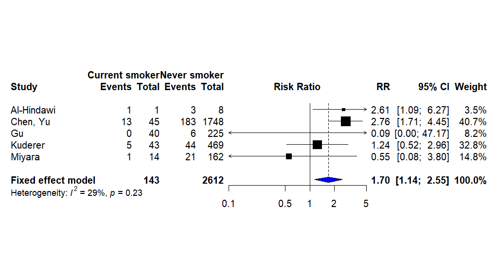

Current versus never smokers

```r
# Data --------------------------------------------------------------------
meta <- tibble('author' = table_5$lead_author,
               'recovered_current_smoker' = table_5$recovered_current_smoking,
               'recovered_never_smoker' = table_5$recovered_never_smoker,
               'death_current_smoker' = table_5$death_current_smokers,
               'death_never_smoker' = table_5$death_never_smokers,
               'recovered_former_smoker' = table_5$recovered_former_smoker,
               'death_former_smoker' = table_5$death_former_smokers) %>%
  filter(author %in% included_studies$lead_author)

meta$author <- to_upper_camel_case(meta$author, sep_out = ", ")
meta$author <- plyr::mapvalues(meta$author,
                               from = cleaned_names,
                               to = correct_names)


# Current smoker mortality ------------------------------------------
event_rates_smoker <- meta %>%
  mutate(., Ee = death_current_smoker) %>%
  mutate(., Ne = (death_current_smoker+recovered_current_smoker)) %>%
  mutate(., Ec = death_never_smoker) %>%
  mutate(., Nc = (death_never_smoker+recovered_never_smoker)) %>%
  rename('Author' = author) %>%
  select(Author, Ee, Ne, Ec, Nc)

event_rates_smoker <- metabin(Ee,
                              Ne,
                              Ec,
                              Nc,
                              data = event_rates_smoker,
                              studlab = paste(Author),
                              comb.fixed = T,
                              comb.random = F,
                              method.tau = 'SJ',
                              hakn = F,
                              prediction = F,
                              incr = 0.1,
                              sm = 'RR')
png(here::here('reports', 'figure', 'fig_9.png'), width=1024, height=546, res=120)
current_smoker_mortality <- forest(event_rates_smoker,
                                         sortvar = Author,
                                         xlim = c(0.1, 5),
                                         rightlabs = c('RR', '95% CI', 'Weight'),
                                         leftlabs = c('Author', 'logRR', 'SE'),
                                         lab.e = 'Current smoker',
                                         lab.c = 'Never smoker',
                                         print.tau2 = F,
                                         col.diamond = 'blue',
                                         col.diamond.lines = 'black',
                                         col.square = 'black',
                                         col.square.lines = 'black',
                                         digits.sd = 2)
null <- dev.off()

event_rates_smoker
```

```r
# Former smoker mortality ------------------------------------------
event_rates_former <- meta %>%
  mutate(., Ee = death_former_smoker) %>%
  mutate(., Ne = (death_former_smoker+recovered_former_smoker)) %>%
  mutate(., Ec = death_never_smoker) %>%
  mutate(., Nc = (death_never_smoker+recovered_never_smoker)) %>%
  rename('Author' = author) %>%
  select(Author, Ee, Ne, Ec, Nc)

event_rates_former <- metabin(Ee,
                              Ne,
                              Ec,
                              Nc,
                              data = event_rates_former,
                              studlab = paste(Author),
                              comb.fixed = T,
                              comb.random = F,
                              method.tau = 'SJ',
                              hakn = F,
                              prediction = F,
                              incr = 0.1,
                              sm = 'RR')
png(here::here('reports', 'figure', 'fig_10.png'), width=1024, height=546, res=120)
former_smoker_mortality <- forest(event_rates_former,
                                         sortvar = Author,
                                         xlim = c(0.1, 5),
                                         rightlabs = c('RR', '95% CI', 'Weight'),
                                         leftlabs = c('Author', 'logRR', 'SE'),
                                         lab.e = 'Former smoker',
                                         lab.c = 'Never smoker',
                                         print.tau2 = F,
                                         col.diamond = 'blue',
                                         col.diamond.lines = 'black',
                                         col.square = 'black',
                                         col.square.lines = 'black',
                                         digits.sd = 2)
null <- dev.off()

event_rates_former
```

```
##                RR           95%-CI %W(fixed)
## Al-Hindawi 1.4545 [0.5500; 3.8467]       5.9
## Kuderer    2.0926 [1.4645; 2.9900]      48.6
## Miyara     2.1905 [1.2919; 3.7141]      18.8
## Chen, Yu   1.7367 [1.0224; 2.9500]      17.9
## Gu         1.9886 [0.7771; 5.0893]       8.7
##
## Number of studies combined: k = 5
##
##                        RR           95%-CI    z  p-value
## Fixed effect model 2.0004 [1.5683; 2.5515] 5.58 < 0.0001
##
## Quantifying heterogeneity:
##  tau^2 = 0.0038 [0.0000; 0.0796]; tau = 0.0618 [0.0000; 0.2821];
##  I^2 = 0.0% [0.0%; 2.6%]; H = 1.00 [1.00; 1.01]
##
## Test of heterogeneity:
##     Q d.f. p-value
##  0.85    4  0.9310
##
## Details on meta-analytical method:
## - Mantel-Haenszel method
## - Sidik-Jonkman estimator for tau^2
## - Q-profile method for confidence interval of tau^2 and tau
```

```r
running_meta_count <- running_meta_count %>%
  full_join(., meta %>%
  rename("study" = author), by = "study") %>%
  select(study)
```

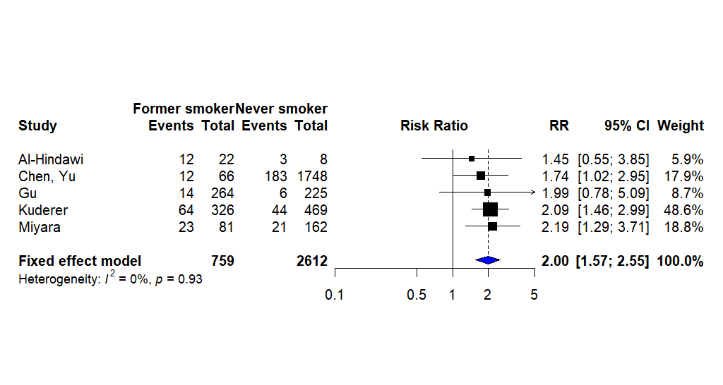

Former versus never smokers

### 0.5.6 Study quality assessment

```r
#Table 6
fair <- nrow(filter(quality_rating, quality_rating$overall_quality == "fair" ))
poor <- nrow(filter(quality_rating, quality_rating$overall_quality == "poor" ))
```

The number of **Fair** quality studies are 28 with the number of **Poor** quality studies equal to 120

The number of studies included in **Meta-analysis** are 23